# Method Section 3.

In this Matlab Live script, we provide the setup and the functions to repeat the simulations and results presented in Thiele et al., "Personalized whole-body models integrate metabolism, physiology, and the gut microbiome".

Table of Contents

3.0. Prerequisites 3.1. Load the whole-body metabolic models: Harvetta (female model) and Harvey (male model) 3.2. Repeat the parameterization of the provided WBM models. 3.3. Compute Basal Metabolic Flux of the whole-body metabolic model 3.4. Compute fat storage and muscle energy expenditure under different dietary constraints 3.5. Compute metabolic organ essentiality 3.6. Statistics on the whole-body metabolic reconstructions 3.7. Organ compendium from whole-body metabolic models 3.8. Predict metabolite biomarkers for 57 inborn-errors of metabolism (IEMs) 3.9. Determine BMF for measured BMR data 3.10. Host-microbiome modeling

## 3.0. Prerequisites

- MATLAB, Mathworks, Inc.
- The COBRA Toolbox (0), to be obtained here: https://opencobra.github.io/cobratoolbox/stable/installation.html
- The PSCM Toolbox extension for the COBRA Toolbox is required.
- The violin plot functions by Bastian Bechtold, to be obtained here: https://github.com/bastibe/Violinplot-Matlab
- A linear and quadratic programming solver. The code has been tested using the Tomlab interface (TomOpt, Inc.) to ILog cplex (solver tomlab_cplex in the COBRA toolbox) as well as IBM ILog Cplex API (academic version, solver ILOGcomplex in the COBRA toolbox ).
- Optional: Access to a high-performance computer or computing facility to improve computation time.

Please increase your MATLAB java heap memory to maximum (see here for details: https://uk.mathworks.com/help/matlab/matlab_external/java-heap-memory-preferences.html).

Initiate the COBRA toolbox

```matlab
if 0
    initCobraToolbox;
end
global useSolveCobraLPCPLEX
useSolveCobraLPCPLEX=0; % set to 0 to use optimizeWBModel (requires COBRA v3 compatible model structure)
global saveDiary
saveDiary = 0; %set to 0 to not print out a diary for each organ
```

Add path to PSCM Toolbox and its subfolders, except the SuppliedResults folder, which are provided with the paper and are separate from the Results folder which is were the results of running this narrative are stored. Setting up the right paths in the first instance requires you to be in the toolbox folder containing MethodSection3.mlx.

```matlab
PSCMPath = which('MethodSection3.mlx');
if isempty(PSCMPath)
    error('Please navigate to the folder containing the MethodSection3.mlx and start running the LiveScript again.');
    return;
end
PSCMPath = strrep(PSCMPath,'MethodSection3.mlx','');
addpath(genpath(PSCMPath));
global resultsPath
resultsPath = which('MethodSection3.mlx');
resultsPath = strrep(resultsPath,'MethodSection3.mlx',['Results' filesep]);
if ~exist(resultsPath,'dir')
    mkdir(resultsPath)
end
%show where the results will be saved
resultsPath
```

resultsPath = '/Users/inesthiele/Desktop/PSCM/Results/'

By default, this script will compute all results, but one can set computeResults = 0 to instead load previously computed results from the SuppliedResults folder, for those computations that are quite time consuming, especially on a desktop computer.

```matlab
global computeResults
computeResults = 0;
if computeResults
    %avoid loading results supplied with the paper by removing directory from
    %the matlab path
    suppliedResultsPath = which('MethodSection3.mlx');
    suppliedResultsPath = strrep(suppliedResultsPath,'MethodSection3.mlx',['SuppliedResults' filesep]);
    rmpath(suppliedResultsPath)
end
```

Generate documentation of the PSCM Toolbox using the m2html tool (https://www.artefact.tk/software/matlab/m2html/).

To access the documentation, please open index.html in your preferred web browser.

```matlab
if 0
    currentPath = pwd;
    % First, convert Matlab LiveScript into a m file:
    matlab.internal.liveeditor.openAndConvert('MethodSection3.mlx','MethodSection3.m');
    % copy the m2html tool from the PSCM Toolbox
    copyfile 'ext/m2html' '../../m2html' 'f'
    % delete any pre-existing documentation of the PSCM Toolbox
    cd ../;
    rmdir PSCM_toolbox_doc s
    cd ../;
    % add path to the m2html tool
    addpath(genpath('m2html'));
    % generate new documentation in target folder 'PSCM_toolbox/PSCM_toolbox_doc/'
    m2html('mfiles','src', 'htmldir','PSCM_toolbox_doc', 'recursive','on', 'global','on','template','brain', 'index','menu');
    cd(currentPath);
end
```

Define the LP and QP solver:

```matlab
if 1
    %LPSolver = 'tomlab_cplex';
    %QPSolver = 'tomlab_cplex';
      LPSolver = 'ibm_cplex';
      QPSolver = 'ibm_cplex';
else
    LPSolver = 'ILOGcomplex';
    QPSolver = 'ILOGcomplex';
end
[solverOK, solverInstalled] = changeCobraSolver(LPSolver, 'LP',0,1);
[solverOK, solverInstalled] = changeCobraSolver(QPSolver, 'QP',0,1);
```

## 3.1. Load the whole-body metabolic models: Harvetta (female model) and Harvey (male model)

The models have been parameterized using the average European diet, the standard physiological parameters, and metabolite concentrations derived from HMDB (1) for plasma/blood, urine, and CSF. The organ metabolite uptake reactions, the exchange reactions across the blood-brain-barrier, the urine excretion reactions, and the kidney exchange reactions have been set accordingly.

```matlab
male = loadPSCMfile('Harvey');
```

useSolveCobraLPCPLEX = 0

```matlab
female = loadPSCMfile('Harvetta');
```

useSolveCobraLPCPLEX = 0

## 3.2. Repeat the parameterization of the provided WBM models.

3.2.1 We will load the standard (default) physiological parameters, which are held on the structure IndividualParameters.

For the male:

```matlab
sex = 'male';
standardPhysiolDefaultParameters;
```

Col = 2

```matlab
IndividualParameters_male = IndividualParameters
```

IndividualParameters_male = struct with fields:

OrgansWeights: {53×3 cell} ID: 'Default' bodyWeight: 70 Height: 170 sex: 'male' HeartRate: 67 StrokeVolume: 80 CardiacOutput: 5360 Hematocrit: 0.4000 MConUrCreatinineMax: 1.2000 MConUrCreatinineMin: 0.5000 MConDefaultBc: 20 MConDefaultCSF: 20 MConDefaultUrMax: 20 MConDefaultUrMin: 0 CSFFlowRate: 0.3500 CSFBloodFlowRate: 0.5200 UrFlowRate: 2000 GlomerularFiltrationRate: 90 bloodFlowData: {32×8 cell} bloodFlowRow: 2 bloodFlowPercCol: [4 6] bloodFlowOrganCol: 1

and for the female:

```matlab
sex = 'female';
standardPhysiolDefaultParameters;
IndividualParameters_female = IndividualParameters
```

IndividualParameters_female = struct with fields:

OrgansWeights: {53×3 cell} ID: 'Default' bodyWeight: 58 Height: 160 sex: 'female' HeartRate: 67 StrokeVolume: 80 CardiacOutput: 5360 Hematocrit: 0.4000 MConUrCreatinineMax: 1.2000 MConUrCreatinineMin: 0.5000 MConDefaultBc: 20 MConDefaultCSF: 20 MConDefaultUrMax: 20 MConDefaultUrMin: 0 CSFFlowRate: 0.3500 CSFBloodFlowRate: 0.5200 UrFlowRate: 2000 GlomerularFiltrationRate: 90 bloodFlowData: {32×8 cell} bloodFlowRow: 2 bloodFlowPercCol: [4 6] bloodFlowOrganCol: 1

Note that the organ weight percentage is defined in the file:

- Numbers_organWeightData_fromxls_16_01_29_OrganWeigths.txt

and can be accessed via

- getOrganWeightFraction.m

For the reference man (Harvey) and woman (Harvetta), the data have been derived as follows:

Organ weight and fractions (organs in bold are currently considered in the whole-body metabolic model as an organ or cell type):

- Total body weight: male: 70 kg; female: 58 kg.
- Adipocytes: male: 15 kg (21.43%); female: 19 kg (32.76%) (2)
- Adrenal glands: male: 14 g (0.02%); female: 14 g (0.024%) (2, 3)
- Brain: male: 1400 g (2%); female: 1200 g (2.069%) (2, 4)
- Breast: male: 26 g (0.037%); female: 360 g (0.621%) (2, 5)
- Colon: estimated based on weight and length of the small intestine, which has a weight of 600 g for 610 cm: male: 300g (0.429%); female: 290g (0.5%) (2, 6, 7)
- CSF: 100-160 ml CSF, density of CSF: 1.0063 to 1.0075: male: 120 g (0.171%); female: 100 g (0.172%) (2, 8)
- Esophagus: estimated based on weight and length of the small intestine, which has a weight of 600 g for 610 cm: male: 40 g (0.057%); female: 34 g (0.059%) (2, 6, 7)
- Heart: male: 331 g (0.473%); female: 253 g (0.436%) (2, 9)
- Kidney: 129 g (right kindey), 137 g (left kidney): male: 310 g (0.443%); female: 275 g (0.474%) (2, 4)
- Liver: male: 1800 g (2.571%); female: 1400 g (2.414%) (2, 4)
- Lung: bloodless: male: 536 g (0.766%); female: 536 g (0.924%) (2, 4)
- Muscle: 38.4 % of body weight in man, 30.6% in woman: male: 28 kg (40%); female: 17 kg (29.310%) (2, 10)
- Ovary: male: 0 g ; female: 11 g (0.019%) (2, 3)
- Pancreas: male: 100 g (0.143%); female: 85 g (0.147%) (2, 3)
- Placenta: male: 0 g; female: 528 g (0.910%) (11, 12)
- Prostate: male: 16 g (0.023%); female: 0 g (2, 3)
- Parathyroid glands: male: 30 mg each for 4 glands; female: 35 mg each for 4 glands: male: 0.12 g (0.000171%); female 0.14 g (0.000241%) (2, 13)
- Rectum: estimated based on weight and length of the small intestine, which has a weight of 600 g for 610 cm: male: 70 g (0.1 %); female: 70 g (0.121%) (2, 6, 7)
- Retina: male: 0.326 g (0.00047%), female: 0.326 g (0.00056%) (14)
- Spinal cord: male: 30 g (0.043%), female: 28 g (0.0483%) (2, 15)
- sIEC: 610 cm long: male: 640 g (0.914%); female: 600 g (1.0344%) [Ref man, 136PMID: 23492669;9400033] (2)
- Skin: male: 2600 g (3.714%); female: 1790 g (3.086%) (2)
- Spleen: male: 180 g (0.257%); female: 150 g (0.259%) (2, 4)
- Stomach: male: 150 g (0.214%); female: 140 g (0.241%) (2, 16)
- Testis: male: 35 g (0.05 %); female: 0 g (2, 3)
- Thyroid gland: male: 20 g (0.029%); female: 17 g (0.029%) (2, 3)
- Urinary bladder: male: 45 g (0.064%); female: 45 g (0.077%) (2, 17)
- Urine in bladder: 300-400 ml: male: 350 g (0.5 %); female: 350 g (0.603%) (18)
- Uterus: male: 0 g; female: 80 g (0.138%) (2, 3)
- Blood: Blood density = 1.0506 g/ml; blood weight = 1050.0663 g/L; 5 l per person assumed: male: 5500 g (7.857%); female: 4100 g (7.069%) (2, 19, 20)
- White blood cells: WBCs in age over 21 year olds: 4.5 to 11.0 (mean 7.4) (in 10^9/L); WBC make about 1% of blood: male: 55 g (0.079%); female: 41 g (0.071%) (21)
- Lymphocytes: 15-40% of WBCs, assumed 30% of WBC weight: male: 16.5 g (0.024%); female: 12.3 g (0.0212%) (22, 23)
- Bcells: 9% of lymphocytes: male: 1.485 g (0.00212%); female: 1.107 g (0.00191%) (23)
- CD4Tcells: 45-75% of lymphocytes, 4 – 20% of leukocyte, assumed 15% of leukocytes: male: 8.25 g (0.0118%); female: 6.15 g (0.0106%) (24)
- CD8Tcells: 2 – 11% of leukocytes, assumed 8%: male: 4.4 g (0.0063%); female: 3.28 g (0.0057%)
- Nkcells: Human and mouse NK cells constitute approximately 15% of all circulating lymphocytes: male: 2.475 g (0.00353%); female: 1.845 g (0.00318%) (24)
- Monocytes: Monocytes account for 2-8% of peripheral WBCs, assumed 5%: male: 2.75 g (0.00393%); female: 2.05 g (0.00353%) (21)
- Platelets: 150,000 to 400,000/mm3, 1mm3 = 1e-6 l, 10 pg per platelet (wet weight), assumed 400k/mm3 corresponding to 4g/l, hence: 20g/5l: male: 20 g (0.0286%); female: 20 g (0.0345%) (25, 26)
- Red blood cells: The normal range in men is approximately 4.7 to 6.1 million cells/ul. The normal range in women range from 4.2 to 5.4 million cells/ul, according to National Institutes of Health data. 27 pg dry weight of one RBC. Assumed 70% water in RBC, hence 90 pg/RBC or 495g/l hence 2475 g/5l for male (assumed 5.5M) and 2050 g/l for female (assumed 4.5M): male: 2475 g (3.536%); female: 2050 g (3.534%) (27, 28)
- Skeleton: (bone, bone marrow, other tissue: male: 10 kg (14.286%); female: 6800 g (11.724%) (2)
- Tendons etc: male: 850 g (1.214%); female: 700 g (1.207%) (2)
- Cervix: estimated: male: 0 g; female: 50 g (0.086%)
- Gall bladder: male: 10 0.014285714 8 0.013793103 (2)
- Gut: content of the gut: male: 1005 g (1.436%); female: 1005 g (1.733%) (2, 29)
- Salivary glands: male: 85 g (0.121%); female: 70 g (0.120%) (2)
- Ureter: male: 16 g (0.023%); female: 15 g (0.026%) (2)
- Urethra: male: 10 g (0.014%); female: 3 g (0.005%) (2)
- Teeth: male: 46 g (0.065%); female: 41 g (0.071%) (2)
- Nails: male: 3 g (0.004%); female: 3 g (0.005%) (2)
- Nose mucosa: male: 32 g (0.046%); female: 27 g (0.047%) (2)
- Hair: male: 20 g (0.029%); female: 300 g (0.517%) (2)

- Total body weight captured by the whole-body model, when excluding bones, nails, etc: male: 58.6kg (83.8%); female: 49,5 kg (85.4%).

3.2.2. Calculation and application of constraints:

- The conversion of a reconstruction into a model involves the definition of condition-specific constraints. To exploit the unique features of the WBM reconstruction, we constrained it with 14 physiological parameters (Fig. 3A, main text), allowing us to quantitatively integrate metabolomics data as modeling constraints. For instance, the metabolite transport across the capillaries of well-perfused organs is bulk flow limited rather than diffusion limited (20). Using blood flow rates at rest for the difference organs and plasma metabolite concentration, obtained from HMDB (1), an upper bound could be placed on metabolite uptake reactions for each organ. Additionally, 80% of the blood is pushed through the kidney along with all metabolites, irrespective of their nature. Multiplying the glomerular filtration rate (GFR) with the plasma metabolite concentration ranges allowed us to set lower and upper bounds for each metabolite uptake by the kidney. Similarly, the cerebrospinal fluid (CSF) content is unselectively flushed into the bloodstream (20), permitting us to set CSF metabolite concentration, obtained from HMDB (1), as constraints. Urine metabolite concentrations, obtained from HMDB (1), can be applied as constraints, knowing the daily urine excretion. Additionally, we included constraints of organ-specific energy requirements (e.g., brain and heart energy demands) as well as organ- and metabolite-specific uptake rates.
- We then apply these physiological constraints, together with the metabolite ranges obtained for urine, blood, and CSF from HMDB. Note that we calculated the ranges for each metabolite in each biofluid based on the data obtained from HMDB (1) for healthy individuals, combining data points for males and females. We combined reported sex-specific metabolite concentrations as the sex- specific information was not available for all metabolites. We assumed ranges to be two standard deviations from the reported mean if no ranges are provided. The used concentration ranges can be found in these files:
- Blood: NormalBloodConcExtractedHMDB.txt;
- CSF: NormalCSFConcExtractedHMDB.txt;
- Urine: NormalUrineConcExtractedHMDB.txt;
- Alternatively, metabolomic data can be also directly put into the function.
- Note that all metabolite concentrations (must be) are given in uM. Note that if no metabolite concentration is given in the HMDB data, then a default blood concentration of 20 uM was assumed for all biofluids. This default can be changed in the structure IndividualParameters.
- The following assumptions were made:
- 1. The modeled system is in a steady-state
- 2. The metabolite transport from, e.g., the arteria (blood vessel) to the organ/tissue is is bulk flow limited, not diffusion limited, which is at least true at higher blood flow rates
- 3. The metabolites can be maximally consumed by a tissue as given by the upper bound (so one tissue could deplete the entire metabolite concentration). Not considering the potential difference between arterial and venal concentration may result in a too high flux rate for a given metabolite and organ/tissue. However, as the venal concentration for most metabolites is unknown, we proceeded with the looser constraints.
- The upper bound on a reaction flux for a given metabolite and organ/tissue is thus calculated based on:
- Q = (ca-cv)*Qv (20)
- vmax_met_organ = conc_met_max * k_blood_organ, where conc_met_max is the maximal metabolite concentration in the blood (as given by the ranges obtained from HMDB) and k_blood_organ is the blood flow percentage for a given organ.
- Note that no organ-specific scaling is necessary as those numbers are already adjusted to organs (in part to weight but also requirements).
- The blood flow rates and percentages for male and female at rest are defined in this file:
- 16_01_26_BloodFlowRatesPercentages.xlsx along with the corresponding references.

3.2.2.1. Glomerular Filtration Rate

- We calculate the glomerular filtration rate as follows:
- RenalFlowRate=BloodFlowPercentage_Kidney*CardiacOutput*(1-Hematocrit); (in ml/min)
- GlomerularFiltrationRate = RenalFlowRate*RenalFiltrationFraction; (in ml/min), where the RenalFiltrationFraction = 0.2;

3.2.2.2. Calculation of the blood flow and plasma flow rate for each organ

- BloodFlowRate_Organ=BloodFlowPercentage_Organ*CardiacOutput; (in ml/min)
- PlasmaFlowRate_Organ=BloodFlowPercentage_Organ*CardiacOutput*(1-Hematocrit); (in ml/min)
- Note than if no information is provided for the organ, 1% was assumed
- BloodFlowRate_Organ=0.01*CardiacOutput; % k_blood_organ in ml/min
- PlasmaFlowRate_Organ=0.01*CardiacOutput*(1-Hematocrit); % k_blood_organ in ml/min
- Flow accross the blood-brain-barrier (exchange from blood compartment to CSF), to supply the spinal cord and the brain
- B = BloodFlowPercentage_Brain + BloodFlowPercentage_Scord;
- BloodFlowRate_BBB=(B)*CardiacOutput; (in ml/min)
- PlasmaFlowRate_BBB=(B)*CardiacOutput*(1-Hematocrit); (in ml/min)

3.2.2.3. Calculation of the upper bound on each metabolite exchange from the blood compartment ([bc]) to the organ/tissue

- Note that the metabolite concentration is given in umol/L, thus it needs to be multiplied by 1000 to result in mmol/L. The PlasmaFlowRate is in (ml/min), hence
- PlasmaFlowRate = PlasmaFlowRate*60*24/1000 to obtain it in L/day.

Kidney:

- The kidney exchange reaction is defined as
- Kidney_EX_metabolite(e)_[bc]: 1 metabolite[e] <--> 1 metabolite[bc]
- Consequently, the upper bound for each kidney reaction is set with
- modelConstraint.ub = -1*(/1000)*GlomerularFiltrationRate*60*24/1000; (in mmol/day/person)
- and the lower bound:
- modelConstraint.lb = -1*(MConMax/1000)*GlomerularFiltrationRate*60*24/1000; % in mmol/day/person
- where MConMin and MConMax are the minimum and maximum concentration values, respectively, for a metabolite as given by the ranges obtained from HMDB.
- Note that in the case of the kidney the lower and upper bounds can be set (in contrast to the other organs, as discussed above) as about 80% of the blood is pushed through the kidney independent of the nature of the metabolite.
- Also, note that we only set the upper bound on these reactions, when the MConMax>=MaxConcConstraint, which is currently defined as 50 uM. This softening was introduced during the debugging process and can be changed in the function physiologicalConstraintsHMDBbased.m as needed.

Other organs supplied by the blood compartment:

- The lower bound for each organ exchange reaction is set with
- modelConstraint.lb = -1*((MConMax)/1000)*PlasmaFlowRate(i,1)*60*24/1000; (in mmol/day/person)
- while the upper bound was unconstrained for all organs that can secrete into the blood compartment or 0 for the remaining organs (i.e., 'sIEC', 'Colon','Spleen','Pancreas','Gall','Brain','Scord').
- Note that if the metabolite concentration was below 1 nM, then the value for MConMax was overwritten to be 1 nM (or 1e-3 uM). This adjustment became necessary during the debugging process.

3.2.2.4. Blood-brain-barrier metabolite exchange reaction constraints

- The constraints for these reactions were based on the blood metabolite concentration and calculated as described in 2.2.3 under "Other organs".

3.2.2.5. CSF concentrations

- No constraints could be put on the metabolite uptake reactions in the brain and the spinal cord as the flux is likely to be diffusion limited, if not active transport system exists, due to the slow flow rate of the CSF (there are about 300 ml of CSF in the brain, which gets completely exchanged about 5 times a day into the blood). However, the exchange/drainage of CSF metabolites into the blood appears to be again independent of the nature of the metabolites and thus bulk flow limitation, rather than diffusion limitation can be assumed. Consequently, we can apply the CSF metabolite concentrations to those CSF excretion reactions, defined as:
- BBB_METABOLITE(CSF)_[bc]exp: 1 metabolite[CSF] --> 1 metabolite[bc]
- The constraints were calculated as follows, lower bound:
- modelConstraint.lb = (MConMin/1000)*CSFBloodFlowRate*60*24/1000; (in mmol/day/person)
- and upper bound:
- modelConstraint.ub = (MConMax/1000)*CSFFlowRate*60*24/1000;
- where MConMin and MConMax are the minimum and maximum metabolite concentration in CSF, respectively. If no metabolite concentration value is provided, MConMin was set to 0 mM and MConMax to 20 mM, as defined in the structure IndividualParameters.

3.2.2.6. Urine concentrations

- The urine excretion reactions are defined as
- EX_metabolite[u]: 1 metabolite[u] -->
- The constraints were calculated as follows, lower bound:
- modelConstraint.lb = (MConMin/1000)*MConDefaultUrCreatinineMin*UrFlowRate/1000; (in mmol/day/person)
- and upper bound
- modelConstraint.ub = (MConMax/1000)*MConDefaultUrCreatinineMax*UrFlowRate/1000; % in mmol/day/person
- where MConMin and MConMax are the minimum and maximum metabolite concentration in the urine, respectively. If no metabolite concentration value is provided, MConMin was set to 0 mM and MConMax to 20 mM, as defined in the structure IndividualParameters. The MConDefaultUrCreatinineMax is the creatinine concentration in the urine and UrFlowRate is the daily urine flow rate. Both are defined in the structure IndividualParameters (see above).
- Note that the lower bound was only set for those metabolites that had a MConMax of at least 50 mM. This softening of constraints became necessary during the debugging process.

3.2.2.7. Further constraints

- Oxygen uptake bounds (at rest)

- The following assumptions and calculations were done:
- - Composition air in: 78.62% nitrogen, 21% oxygen, 0.96% argon, 0.04% carbon dioxide, 0.5% water vapour
- - Composition air out: 78.04% nitrogen, 14% - 16% oxygen, 4% - 5.3% carbon dioxide, 1% argon and other gases
- - Amount of O2:
- - Tidal volume: 500 ml/breath
- - Breathing frequency 12-15x/min
- - Change of O2: 5%
- - Volume of gas: 1mol gas = 22.4 l , 1mmol=22.4ml
- - Volume O2/breath = 5*500 (ml)/100 = 25ml
- - O2 change (mmol) = 25ml/22.4 ml = 1.1mmol
- - Volume 02/day = 1.1mmol*12*60*24 = 19080 mmol/day/person
- - We assumed a respiratory quotient of 0.8 to set the CO2 outflux accordingly
- - As the oxygen uptake rate (aka, oxygen consumption at rest) depends on the calculation and differs between individuals, we choose a range to constraint the default Harvey and Harvetta models: (33-35)
- lower bound on O2 uptake = -25000;
- upper bound on O2 uptake = -15000;
- lower bound on CO2 secretion = -15000*0.8;
- upper bound on CO2 secretion = -25000;
- Water exchange:
- values were taken from (2). For each calculated value, we assumed a 20% error. Consequently, the constraints are:
- Sweat: 650 ml (water loss)/day - 650g = 650g/day / 18.01528g/mol = 36.0805 mol/day/person
- lower bound on EX_h2o[a] = 36080*0.8
- upper bound on EX_h2o[a] = 36080*1.2
- Insensible (assumed to be breathing): 840g = 850/18.01528 = 47.1822 mol/day/person
- lower bound on EX_h2o[sw] = 47182*0.8
- upper bound on EX_h2o[sw] = 47182*1.2
- Urine: 1400g = 1400/18.01528 = 77.7118 mol/day/person
- lower bound on EX_h2o[u] = 77711*0.8
- upper bound on EX_h2o[u] = 77711*1.2
- Feces: 100g = 100/18.01528 = 5.5508 mol/day/person
- lower bound on Excretion_EX_h2o[fe = 5550*0.8
- upper bound on Excretion_EX_h2o[fe] = 5550*1.2
- To limit the water secretion into bile duct, we set an arbitrary value as upper bound on the corresponding reaction
- upper bound on Gall_H2Ot[bdG] = 1000
- upper bound on Liver_H2Ot[bdL] = 1000

Specific reactions

- Alanine secretion of the muscle is 12.5 mg alanine/min/person (65 kg) in the postabsorption state (36)

- MW of alanine is MW = 89.09; % g·mol-1
- hence, met = (met * 60 * 24 *IndividualParameters.bodyWeight/65)/1000; %g per day per person (weight adjusted) and met = met * 1000/ MW ; %mmol per day per person (weight adjusted)
- lower bound on Muscle_EX_ala_L(e)_[bc] = met*0.8 (in mmol/day/person)
- upper bound on Muscle_EX_ala_L(e)_[bc] = met*1.2

- Glucose uptake of RBCs is 25 mg/glc/min/person (65kg) (36)

- MW of glucose is MW = 180.16; % g·mol-1
- hence, met = (met * 60 * 24 *IndividualParameters.bodyWeight/65)/1000; %g per day per person (weight adjusted) and met = met * 1000/ MW; %mmol per day per person (weight adjusted)
- lower bound on RBC_EX_glc_D(e)_[bc] = -met*0.8
- upper bound on RBC_EX_glc_D(e)_[bc] = -met*1.2

- Glucose uptake of the brain is 80 mg glc/min/person (36)

- MW of glucose is MW = 180.16; % g·mol-1
- met = (met * 60 * 24 *IndividualParameters.bodyWeight/65)/1000; %g per day per person (weight adjusted) and met = met * 1000/ MW; %mmol per day per person (weight adjusted)
- lower bound on Brain_EX_glc_D(e)_[CSF] = -met*0.8
- upper bound on Brain_EX_glc_D(e)_[CSF] = -met*1.2

- Brain oxygen uptake flux

- brain_weight is defnined in structure IndividualParameters
- Brain oxygen uptake is 156 umol o2/100g brain/min; (37)
- hence, brain_o2 = (brain_o2 * 60 * 24 * brain_weight/100)/1000; %mmol o2/person (brain)/day.
- lower bound on Brain_EX_o2(e)_[CSF] = -brain_o2*1.2
- upper bound on Brain_EX_o2(e)_[CSF] = -brain_o2*0.7

- Alanine uptake of the liver is 12.5 mg alanine/min/person (65 kg) in postabsorption state (36)

- MW of alanine is MW = 89.09; % g·mol-1
- hence, met = (met * 60 * 24 *IndividualParameters.bodyWeight/65)/1000; %g per day per person (weight adjusted) and met = met * 1000/ MW; %mmol per day per person (weight adjusted)
- lower bound on Liver_EX_ala_L(e)_[bc] = -met*0.8
- upper bound on Liver_EX_ala_L(e)_[bc] = -met*1.2

- Glucose secretion by liver is 130 mg glc/min/person (65 kg) in postabsorption state (36)

- MW of glucose is MW = 180.16; % g·mol-1
- hence, met = (met * 60 * 24 *IndividualParameters.bodyWeight/65)/1000; %g per day per person (weight adjusted) and met = met * 1000/ MW; %mmol per day per person (weight adjusted)
- lower bound on Liver_EX_glc_D(e)_[bc] = met*1.2
- upper bound on Liver_EX_glc_D(e)_[bc] = met*0.8

- Glycerol secretion by adipocytes is 12 mg glycerol/min/person (65 kg) in postabsorption state (36)

- MW of glycerol is MW = 92.09; % g·mol-1
- hence, met = (met * 60 * 24 *IndividualParameters.bodyWeight/65)/1000; %g per day per person (weight adjusted) and met = met * 1000/ MW; %mmol per day per person (weight adjusted)
- lower bound on Adipocytes_EX_glyc(e)_[bc] = met*0.8
- upper bound on Adipocytes_EX_glyc(e)_[bc] = met*1.2

- The brain and the liver can do CO2 fixation (38) and Co2 can cross the BBB (39)

- all organs but the liver and the brains are set not to take up CO2:
- lower bound on Organ_EX_co2(e)_[bc] = 0
- lower bound on Brain_EX_co2(e)_[CSF] = -10000 where -10000 is an arbitrary number
- lower bound on Liver_EX_co2(e)_[bc] = -10000 where -10000 is an arbitrary number
- lower bound on Lung_EX_co2(e)_[bc] = -10000 where -10000 is an arbitrary number
- lower bound on Kidney_EX_co2(e)_[bc] = -10000 where -10000 is an arbitrary number (needed for blood circulation)

Brain ATP requirement

- The brain consumes about 120g glucose per day (40), corresponding to 0.66 mol glucose/day/person (MW=180.16).
- 1 mol glucose can be converted into 31 mol atp; hence 20.46 mol ATP could be theoretically produced from 0.66 mol glucose if complete oxidative phosphorylation is assumed.
- However, the reported value also includes the metabolic activity that we capture already in the whole-body metabolic model. Hence, it can be optionally set to:
- lower bound on Brain_DM_atp_c_ = 5500 (we did not apply this constrain when computing the basal metabolic flux)

Heart energy requirement - minimum based on (41)

- A minimum of 6000g of ATP per day per person is reported. The molecular weight of ATP is 507.18g/mol, hence 11830 mmol ATP/day/person is needed for the pump action of the heart. As the numbers differ between the sources, we enforced a minimum constraint of 6000 mmol ATP/day/person on the Heart_DM_atp_c_ reaction.
- lower bound on Heart_DM_atp_c_ = 6000

```matlab
% apply HMDB metabolomic data based on the female individual parameters
female = physiologicalConstraintsHMDBbased(female,IndividualParameters_female);
male = physiologicalConstraintsHMDBbased(male,IndividualParameters_male);
```

3.2.2.8. Diet constraints

Dietary input defines the possible metabolism of the whole-body model and therefore define the set of attainable metabolic states of the entire body. In total, 1392 dietary components can be defined in the WBM models. However, only limited, quantitative information is currently available for the molecular composition of most food item. For instance, the Österreichische Nährwerttabelle (42) specifies, for more than 16,000 food items, 133 molecular components, 92 of which can be directly mapped onto the whole-body model. Using a newly developed diet designer (43), we defined an average European diet based on an Austrian survey of 1002 people (44) and substituted it with further 23 metabolites, which are known to occur in the diet but for which no quantitative information have been provided in this resource. The VMH lists further diets, which can be used to constrain the WBM models or individual diets can be designed, thereby enabling ultimately assessing the metabolic mechanism of individual dietary regimes on whole-body metabolism or even the prediction of personalized dietary recommendations.

The following diet has been defined. A detailed description can be found in the corresponding mfile and here: http://vmh.life. The diet has been based on food items as suggested by the individual references and a macromolecular composition typical for the corresponding diet.

EUAverageDietNew.m: The "EU diet" was designed based on information from an Austrian Survey. The survey was implemented in the year 2012 and 1002 people from different ages participated being one of the few free available and nutrient-based surveys for European countries (44). The "EU diet" can be used as a control which allows us to examine differences in metabolism due to the variability in the nutritional amounts.

Note that certain additional input constraints were set to enable the growth of gastrointestinal bacteria, as well as to provide the whole-body metabolic model with additional dietary components currently not reported on the used nutritional databases (ONT (42) and USDA (45)). Please read setDietConstraints.m for more details.

```matlab
EUAverageDietNew

female = setDietConstraints(female, Diet);
male = setDietConstraints(male, Diet);
```

3.2.2.9. Simulation/paper specific constraints

Please refer to the corresponding functions for details on constraints. These constraints have been introduced during the debugging process to avoid, e.g., cycling between blood and bile of certain R-Group metabolites or to enable the determination of the maximal capacity flux of, e.g., serotonin in the brain.

```matlab
% set some more constraints
female = setSimulationConstraints(female);

female.lb(strmatch('BBB_KYNATE[CSF]upt',female.rxns)) = -1000000;
female.lb(strmatch('BBB_LKYNR[CSF]upt',female.rxns)) = -1000000;
female.lb(strmatch('BBB_TRP_L[CSF]upt',female.rxns)) = -1000000;
female.ub(strmatch('Brain_EX_glc_D(',female.rxns)) = -100; % currently -400 rendering many of the models to be infeasible in germfree state

minInf = -1000000;
maxInf = 1000000;
minConstraints = length(intersect(find(female.lb>minInf),find(female.lb)));
maxConstraints =length(intersect(find(female.ub<maxInf),find(female.ub)));
PercentageConstraintRxns_female = (minConstraints + maxConstraints)*100/length(female.ub)
```

PercentageConstraintRxns_female = 12.5465

```matlab
% male
% set some more constraints
male = setSimulationConstraints(male);
male.lb(strmatch('BBB_KYNATE[CSF]upt',male.rxns)) = -1000000; %constrained uptake
male.lb(strmatch('BBB_LKYNR[CSF]upt',male.rxns)) = -1000000; %constrained uptake
male.lb(strmatch('BBB_TRP_L[CSF]upt',male.rxns)) = -1000000; %constrained uptake
male.ub(strmatch('Brain_EX_glc_D(',male.rxns)) = -100; % currently -400 rendering many of the models to be infeasible in germfree state

% count how many reactions have a non-infinity bounds
minInf = -1000000;
maxInf = 1000000;
minConstraints = length(intersect(find(male.lb>minInf),find(male.lb)));
maxConstraints =length(intersect(find(male.ub<maxInf),find(male.ub)));
PercentageConstraintRxns_male = (minConstraints + maxConstraints)*100/length(male.ub)
```

PercentageConstraintRxns_male = 12.5015

Print the WBM model

With the following code, the WBM models can be printed. Please note that Matlab cannot print the produced table into a spreadsheet as the number of rows exceeds the allowed number of rows. However, the variable 'table' can be copied into a spreadsheet by double-clicking at the variable in the workspace, selecting its content, copying it (ctrl C), and pasting it into a spreadsheet. Please note that the copying may take a while.

```matlab
% male
if 0
    % remove coupling constraints from the S matrix and the mets vector
    male_wo_coupling = male;
    male_wo_coupling.S(strmatch('slack_',male_wo_coupling.mets),:)=[];
    male_wo_coupling.mets(strmatch('slack_',male_wo_coupling.mets)) = [];
    % print reaction formula into 'rxnFormula'
    [rxnFormula_male]=printRxnFormula(male_wo_coupling,'printFlag',false,'directionFlag',true);
    % create table
    table_male=[male_wo_coupling.rxns,male_wo_coupling.rxnNames,rxnFormula_male,num2cell(male_wo_coupling.lb),num2cell(male_wo_coupling.ub),male_wo_coupling.grRules,male_wo_coupling.subSystems];
    % convert table into cell format for the Matlab function 'writetable'
    cellTable_male = cell2table(table_male);
    % writing the table produces an error as the number of rows exceeds what is
    % permitted by Matlab
    if 0
        writetable(cellTable_male,'WBM_male','FileType','spreadsheet','WriteVariableNames',false);
    end
end

if 0
    % female
    % remove coupling constraints from the S matrix and the mets vector
    female_wo_coupling = female;
    female_wo_coupling.S(strmatch('slack_',female_wo_coupling.mets),:)=[];
    female_wo_coupling.mets(strmatch('slack_',female_wo_coupling.mets)) = [];
    % print reaction formula into 'rxnFormula'
    [rxnFormula_female]=printRxnFormula(female_wo_coupling,'printFlag',false,'directionFlag',true);
    % create table
    table_female=[female_wo_coupling.rxns,female_wo_coupling.rxnNames,rxnFormula_female,num2cell(female_wo_coupling.lb),num2cell(female_wo_coupling.ub),female_wo_coupling.grRules,female_wo_coupling.subSystems];
    % convert table into cell format for the Matlab function 'writetable'
    cellTable_female = cell2table(table_female);
    % writing the table produces an error as the number of rows exceeds what is
    % permitted by Matlab
    if 0
        writetable(cellTable_female,'WBM_female','FileType','spreadsheet','WriteVariableNames',false);
    end
end
```

Save physiologically constrained male and female models

Save the models so that they can be loaded later to restart individual sections of the narrative without having to go back to the beginning.

```matlab
if exist('male','var')
    save([resultsPath 'Harvey_1_03c'],'male')
end
if exist('female','var')
    save([resultsPath 'Harvetta_1_03c'],'female')
end
```

## 3.3. Compute Basal Metabolic Flux of the whole-body metabolic model

The basal metabolic rate (BMR), or resting energy expenditure, defines the metabolic requirement needed to maintain the basic function of the human body. The BMR varies between individuals and over time. Women have generally a lower BMR than men, due to having more body fat. Generally, the energy use can be split as following: basal metabolism accounts for 60-75%, 15-30% are required for physical activity (depending on the level of activity), 5-10 % for food-induced thermogenesis, and 2-7% others (46).

3.3.1. Whole-body biomass reaction and biomass maintenance

Each organ in the whole-body metabolic model contains a biomass maintenance reaction, representing the energetic requirements to maintain the organ's integral function. As the molecular components, e.g., amino acids and lipids are recycled within the body, the maintenance reaction releases these macromolecular precursors as well. Organ-specific biomass maintenance reactions were taken from published reconstructions for four organs, red blood cell (47), the adipocytes (48), the small intestine (6), and the liver (49), and were formulated based on the biomass reaction present in Recon 3* for the other organs. Note that organs known to proliferate under healthy conditions contain a biomass reaction in addition, which can be used to represent organ growth if desired.

The whole-body biomass reaction is composed of the biomass maintenance reactions of each organ, scaled by the organ weight percentage as defined in the structure IndividualParameters. As one person has to maintain its body, the lower and upper bound on the whole-body biomass reaction are set to 1, if not noted differently.

```matlab
if ~exist('male','var')
    male = loadPSCMfile('Harvey');
end
if ~exist('female','var')
    female = loadPSCMfile('Harvetta');
end
% print whole-body biomass reaction
% male
printRxnFormula(male,'Whole_body_objective_rxn');
```

Whole_body_objective_rxn 21.4286 Adipocytes_biomass_maintenance_dummy_objective + 0.02 Agland_biomass_maintenance_dummy_objective + 2 Brain_biomass_maintenance_dummy_objective + 0.428571 Colon_biomass_maintenance_dummy_objective + 0.472857 Heart_biomass_maintenance_dummy_objective + 0.442857 Kidney_biomass_maintenance_dummy_objective + 2.57143 Liver_biomass_maintenance_dummy_objective + 0.765714 Lung_biomass_maintenance_dummy_objective + 40 Muscle_biomass_maintenance_dummy_objective + 0.142857 Pancreas_biomass_maintenance_dummy_objective + 0.0228571 Prostate_biomass_maintenance_dummy_objective + 0.000171429 Pthyroidgland_biomass_maintenance_dummy_objective + 0.000465714 Retina_biomass_maintenance_dummy_objective + 0.0428571 Scord_biomass_maintenance_dummy_objective + 0.914286 sIEC_biomass_reactionIEC01b_dummy_objective + 3.71429 Skin_biomass_maintenance_dummy_objective + 0.257143 Spleen_biomass_maintenance_dummy_objective + 0.214286 Stomach_biomass_maintenance_dummy_objective + 0.05 Testis_biomass_maintenance_dummy_objective + 0.0285714 Thyroidgland_biomass_maintenance_dummy_objective + 0.0642857 Urinarybladder_biomass_maintenance_dummy_objective + 0.00212143 Bcells_biomass_maintenance_dummy_objective + 0.0117857 CD4Tcells_biomass_maintenance_dummy_objective + 0.00353571 Nkcells_biomass_maintenance_dummy_objective + 0.00392857 Monocyte_biomass_maintenance_dummy_objective + 0.0285714 Platelet_biomass_maintenance_noTrTr_dummy_objective + 3.53571 RBC_biomass_maintenance_noTrTr_dummy_objective + 0.0142857 Gall_biomass_maintenance_dummy_objective ->

```matlab
% female
printRxnFormula(female,'Whole_body_objective_rxn');
```

Whole_body_objective_rxn 32.7586 Adipocytes_biomass_maintenance_dummy_objective + 0.0241379 Agland_biomass_maintenance_dummy_objective + 2.06897 Brain_biomass_maintenance_dummy_objective + 0.62069 Breast_biomass_maintenance_dummy_objective + 0.5 Colon_biomass_maintenance_dummy_objective + 0.436207 Heart_biomass_maintenance_dummy_objective + 0.474138 Kidney_biomass_maintenance_dummy_objective + 2.41379 Liver_biomass_maintenance_dummy_objective + 0.924138 Lung_biomass_maintenance_dummy_objective + 29.3103 Muscle_biomass_maintenance_dummy_objective + 0.0189655 Ovary_biomass_maintenance_dummy_objective + 0.146552 Pancreas_biomass_maintenance_dummy_objective + 0.000241379 Pthyroidgland_biomass_maintenance_dummy_objective + 0.000562069 Retina_biomass_maintenance_dummy_objective + 0.0482759 Scord_biomass_maintenance_dummy_objective + 1.03448 sIEC_biomass_reactionIEC01b_dummy_objective + 3.08621 Skin_biomass_maintenance_dummy_objective + 0.258621 Spleen_biomass_maintenance_dummy_objective + 0.241379 Stomach_biomass_maintenance_dummy_objective + 0.0293103 Thyroidgland_biomass_maintenance_dummy_objective + 0.0775862 Urinarybladder_biomass_maintenance_dummy_objective + 0.137931 Uterus_biomass_maintenance_dummy_objective + 0.00190862 Bcells_biomass_maintenance_dummy_objective + 0.0106034 CD4Tcells_biomass_maintenance_dummy_objective + 0.00318103 Nkcells_biomass_maintenance_dummy_objective + 0.00353448 Monocyte_biomass_maintenance_dummy_objective + 0.0344828 Platelet_biomass_maintenance_noTrTr_dummy_objective + 3.53448 RBC_biomass_maintenance_noTrTr_dummy_objective + 0.0862069 Cervix_biomass_maintenance_dummy_objective + 0.0137931 Gall_biomass_maintenance_dummy_objective ->

```matlab
if 0
    % compute the minimal and maximal possible flux through the whole-body biomass reaction
    % reset the bound on this reaction

    %male
    male = changeRxnBounds(male,'Whole_body_objective_rxn',0,'l');
    male = changeRxnBounds(male,'Whole_body_objective_rxn',100,'u');
    % define the objective function
    male = changeObjective(male,'Whole_body_objective_rxn');
    % minimization
    male.osenseStr = 'min';
    solution_male_BMF_Min = optimizeWBModel(male);
    % maximization
    male.osenseStr = 'max';
    [solution_male_BMF_Max] = optimizeWBModel(male);

    %female
    female = changeRxnBounds(female,'Whole_body_objective_rxn',0,'l');
    female = changeRxnBounds(female,'Whole_body_objective_rxn',100,'u');
    % define the objective function
    female = changeObjective(female,'Whole_body_objective_rxn');
    % minimization
    female.osenseStr = 'min';
    solution_female_BMF_Min = optimizeWBModel(female);
    % maximization
    female.osenseStr = 'max';
    [solution_female_BMF_Max]=optimizeWBModel(female);
end
% set lower and upper bound to 1
male = changeRxnBounds(male,'Whole_body_objective_rxn',1,'b');
female = changeRxnBounds(female,'Whole_body_objective_rxn',1,'b');

% clear workspace
clear Numbers i  blood* Body* IndividualParameters file* sex Organ* Object
%clearvars -except male female
```

3.3.2. Compute a unique flux distribution through the whole-body metabolic model.

The linear programming problem posed by most metabolic models is underdetermined, meaning that there are more variables (i.e., reactions) then equations (i.e., mass balances). Consequently, alternative optimal solutions exist to this linear programming problem:

min/max f = c'.v

subject to

S.v = b

lb <= v <= ub

where f is the linear objective function, c a zero vector of length n with at least one non-zero entry at the index of the reaction(s) to be optimized for, and v is the flux vector. S represents the stoichiometric matrix with m rows (number of mass balances) and n number of reactions. v_lb and v_ub are the lower and upper bounds set on the model's reactions, respectively. To obtain a unique flux distribution through the whole-body metabolic model, we minimize the Euclidian norm of the flux vector (with or without a linear objective:

min f = c'.v + ||v||

subject to

S.v = b

lb <= v <= ub

```matlab
% set constraints specific for simulating BMR determination
female.lb(strmatch('Brain_DM_atp',female.rxns)) = 3500;
female.lb(strmatch('Heart_DM_atp',female.rxns)) = 1000;
male.lb(strmatch('Brain_DM_atp',male.rxns)) = 3500;
male.lb(strmatch('Heart_DM_atp',male.rxns)) = 1000;

male.c(:)=0;
param.minNorm = 1e-6;
male.osenseStr = 'min';
solution_male = optimizeWBModel(male, param);
solution_male.stat
```

ans = 1

```matlab
female.c(:)=0;
param.minNorm = 1e-6;
female.osenseStr='min';
solution_female = optimizeWBModel(female, param);
solution_female.stat
```

ans = 1

3.3.2.1. Basal metabolic flux (BMF)

This flux distribution for each whole-body metabolic model can then be used to determine its overall energy consumption, representing its basal metabolic flux (BMF) in order to approximate the BMR. Note that we assumed that under physiological conditions, the hydrolysis of 1 ATP yields 64 kJ (52).

```matlab
% Calculate BMF for the male model
S = male.S;
F = max(-S,0);
R = max(S,0);
vf = max(solution_male.v,0);
vr = max(-solution_male.v,0);
%production=[R, F]*[vf ;vr];
consumption=[F, R]*[vf; vr];
% find all reactions in the model that involve atp
atp = (find(~cellfun(@isempty,strfind(male.mets,'_atp['))));
% sum of atp consumption in the flux distribution
Sum_atp_male=sum(consumption(atp,1)); % (in mmol ATP/day/person)
% compute the energy release in kJ
Energy_kJ_male = Sum_atp_male/1000 * 64; % (in kJ/day/person)

% compute the energy release in kcal, where 1 kJ = 0.239006 kcal
Energy_kcal_male = Energy_kJ_male*0.239006 % (in kcal/day/person)
```

Energy_kcal_male = 1.4558e+03

```matlab
% Calculate BMF for the female model
S = female.S;
F = max(-S,0);
R = max(S,0);
vf = max(solution_female.v,0);
vr = max(-solution_female.v,0);
%production=[R F]*[vf; vr];
consumption=[F R]*[vf; vr];
% find all reactions in the model that involve atp
atp = (find(~cellfun(@isempty,strfind(female.mets,'_atp['))));
% sum of atp consumption in the flux distribution
Sum_atp_female=sum(consumption(atp,1)); % (in mmol ATP/day/person)
% compute the energy release in kJ
Energy_kJ_female = Sum_atp_female/1000 * 64; % (in kJ/day/person)

% compute the energy release in kcal, where 1 kJ = 0.239006 kcal
Energy_kcal_female = Energy_kJ_female*0.239006 % (in kcal/day/person)
```

Energy_kcal_female = 1.3449e+03

The computed BMF values for the female and male compare well with those obtained using phenomenological models, such as the Mifflin - St Jeor equations (53):

Male: BMR = 10 * weight (in kg) + 6.25*height (in cm) - 5*age (in years) + 5;

Female: BMR = 10*weight (in kg) + 6.25*height (in cm) - 5*age (in years) - 161

As there is no age reported for the reference man and woman, which the physiological parameters were based on, we compute the BMR at age 20 and at age 40:

```matlab
% male
BMR_male_20 = calculateBMR('male', 70, 170, 20);
BMR_male_40 = calculateBMR('male', 70, 170, 40);

{'Based on Harvey' 'Mifflin-St Jeor at age 20' 'Mifflin-St Jeor at age 40';num2str(Energy_kcal_male) num2str(BMR_male_20(3,:)) num2str(BMR_male_40(3,:))}
```

ans = 2×3 cell array

'Based on Harvey' 'Mifflin-St Jeor at age 20' 'Mifflin-St Jeor at age 40'  
'1455.8218' '1667.5' '1567.5'

```matlab
% female
BMR_female_20 = calculateBMR('female', 58, 160, 20);
BMR_female_40 = calculateBMR('female', 58, 160, 40);

{'Based on Harvetta'  'Mifflin-St Jeor at age 20' 'Mifflin-St Jeor at age 40';  num2str(Energy_kcal_female) num2str( BMR_female_20(3,:)) num2str( BMR_female_40(3,:))}
```

ans = 2×3 cell array

'Based on Harvetta' 'Mifflin-St Jeor at age 20' 'Mifflin-St Jeor at age 40'  
'1344.8623' '1319' '1219'

```matlab
% calculate the atp consumed by organ biomass reactions

% find all biomass reactions
BM = (find(~cellfun(@isempty,strfind(male.rxns,'_biomass_'))));

% find all reactions in the model that involve atp
atp = (find(~cellfun(@isempty,strfind(male.mets,'_atp['))));
BMatpSum = 0;
for i = 1: length(BM)
    % grab atp
    BMmets = (find(male.S(:,BM(i))));
    BMatp(i,1) = intersect(BMmets,atp);
    BMatpCoeff(i,1) = male.S(BMatp(i,1),BM(i));
    BMatpSum = BMatpSum + BMatpCoeff(i,1)*solution_male.v(BM(i));
end

% sum of atp consumption in the flux distribution
Sum_BM_atp_male=abs(BMatpSum); % (in mmol ATP/day/person)
% compute the energy release in kJ
Energy_BM_atp_kJ_male = Sum_BM_atp_male/1000 * 64; % (in kJ/day/person)

% compute the energy release in kcal, where 1 kJ = 0.239006 kcal
Energy_BM_atp_kcal_male = Energy_BM_atp_kJ_male*0.239006 % (in kcal/day/person)
```

Energy_BM_atp_kcal_male = 26.9637

```matlab
% female
BM = (find(~cellfun(@isempty,strfind(female.rxns,'_biomass_'))));

% find all reactions in the model that involve atp
atp = (find(~cellfun(@isempty,strfind(female.mets,'_atp['))));
BMatpSum = 0;
for i = 1: length(BM)
    % grab atp
    BMmets = (find(female.S(:,BM(i))));
    BMatp(i,1) = intersect(BMmets,atp);
    BMatpCoeff(i,1) = female.S(BMatp(i,1),BM(i));
    BMatpSum = BMatpSum + BMatpCoeff(i,1)*solution_female.v(BM(i));
end

% sum of atp consumption in the flux distribution
Sum_BM_atp_female=abs(BMatpSum); % (in mmol ATP/day/person)
% compute the energy release in kJ
Energy_BM_atp_kJ_female = Sum_BM_atp_female/1000 * 64; % (in kJ/day/person)

% compute the energy release in kcal, where 1 kJ = 0.239006 kcal
Energy_BM_atp_kcal_female = Energy_BM_atp_kJ_female*0.239006 % (in kcal/day/person)
```

Energy_BM_atp_kcal_female = 21.5525

```matlab
% clear workspace
clear F R vf vr S prod* consu* ans atp
```

3.3.2.2. Flux through the Cori and Cahill-cycles

The computed unique flux distribution can be used to verify that both the Cori (glucose-lactate) and the Cahill (glucose-alanine) cycles are active in the whole-body metabolic models (and in this flux distribution).

```matlab
% female model
% Cori cycle flux
CoriCycleRxns = {
    % Liver:
    'Liver_GALU';'Liver_HMR_0761';'Liver_GBA';...
    'Liver_EX_glc_D(e)_[bc]';  'Liver_PGMT'; 'Liver_PGI'; ...
    'Liver_LDH_L'; 'Liver_EX_lac_L(e)_[bc]';...
    %Muscle:
    'Muscle_EX_glc_D(e)_[bc]'; 'Muscle_HEX1'; 'Muscle_PYK';  'Muscle_LDH_L';'Muscle_EX_lac_L(e)_[bc]' };

for i = 1 : length(CoriCycleRxns)
    CoriCycleRxns(i,2) = printRxnFormula(female,female.rxns(strmatch(CoriCycleRxns{i,1},...
        female.rxns,'exact')),0);
    CoriCycleRxns{i,3} = num2str(solution_female.v(strmatch(CoriCycleRxns{i,1},...
        female.rxns,'exact')));
end
CoriCycleRxns
```

CoriCycleRxns = 13×3 cell array

'Liver_GALU' 'Liver_h[c] + Liver_g1p[c] +… '103.2117'  
'Liver_HMR_0761' 'Liver_crm_hs[c] + Liver_udp… '82.0247'  
'Liver_GBA' 'Liver_h2o[c] + Liver_glusid… '88.0535'  
'Liver_EX_glc_D(e)_[bc]' 'Liver_glc_D[e] -> glc_D[bc] ''967.6933'  
'Liver_PGMT' 'Liver_g1p[c] <=> Liver_g6p… '40.2786'  
'Liver_PGI' 'Liver_g6p[c] <=> Liver_f6p… '-755.2445'  
'Liver_LDH_L' 'Liver_nad[c] + Liver_lac_L[… '855.06'  
'Liver_EX_lac_L(e)_[bc]' 'Liver_lac_L[e] <=> lac_L[b… '-1144.3417'  
'Muscle_EX_glc_D(e)_[bc]' 'Muscle_glc_D[e] <=> glc_D[… '-10'  
'Muscle_HEX1' 'Muscle_atp[c] + Muscle_glc_… '49.7871'

```matlab
CahillCycleRxns = {
    % Liver:
    'Liver_EX_glc_D(e)_[bc]';  'Liver_PGMT'; 'Liver_PGI'; 'Liver_ALATA_L';...
    'Liver_EX_ala_L(e)_[bc]';...
    'Liver_GALU';'Liver_HMR_0761';'Liver_GBA';...
    % Muscle
    'Muscle_EX_glc_D(e)_[bc]'; 'Muscle_HEX1'; 'Muscle_PYK';  'Muscle_ALATA_L'; ...
    'Muscle_EX_ala_L(e)_[bc]';
    };

for i = 1 : length(CahillCycleRxns)
    CahillCycleRxns(i,2) = printRxnFormula(female,female.rxns(strmatch(CahillCycleRxns{i,1},...
        female.rxns,'exact')),0);
    CahillCycleRxns{i,3} = num2str(solution_female.v(strmatch(CahillCycleRxns{i,1},...
        female.rxns,'exact')));
end
CahillCycleRxns
```

CahillCycleRxns = 13×3 cell array

'Liver_EX_glc_D(e)_[bc]' 'Liver_glc_D[e] -> glc_D[bc] ''967.6933'  
'Liver_PGMT' 'Liver_g1p[c] <=> Liver_g6p… '40.2786'  
'Liver_PGI' 'Liver_g6p[c] <=> Liver_f6p… '-755.2445'  
'Liver_ALATA_L' 'Liver_akg[c] + Liver_ala_L[… '112.4347'  
'Liver_EX_ala_L(e)_[bc]' 'Liver_ala_L[e] <=> ala_L[b… '-144.2275'  
'Liver_GALU' 'Liver_h[c] + Liver_g1p[c] +… '103.2117'  
'Liver_HMR_0761' 'Liver_crm_hs[c] + Liver_udp… '82.0247'  
'Liver_GBA' 'Liver_h2o[c] + Liver_glusid… '88.0535'  
'Muscle_EX_glc_D(e)_[bc]' 'Muscle_glc_D[e] <=> glc_D[… '-10'  
'Muscle_HEX1' 'Muscle_atp[c] + Muscle_glc_… '49.7871'

```matlab
if 0
    maleMod = male;
    Bounds = [male.lb(find(ismember(male.rxns,CoriCycleRxns))) male.ub(find(ismember(male.rxns,CoriCycleRxns)))];
    %maleMod = changeRxnBounds(maleMod,'Muscle_EX_glc_D(e)_[bc]',0,'u'); % uptake enforcement needed for Cori & Cahill cycles
    %maleMod = changeRxnBounds(maleMod,'Muscle_EX_ala_L(e)_[bc]',0,'l'); % secretion enforcement needed for  Cahill cycle
    maleMod = changeRxnBounds(maleMod,'Liver_EX_glc_D(e)_[bc]',0,'l'); % secretion enforcement NOT needed for Cori & Cahill cycles
    %maleMod = changeRxnBounds(maleMod,'Liver_EX_ala_L(e)_[bc]',0,'u'); % uptake enforcement needed for Cahill cycle

    maleMod.c(:)=0;
    maleMod.osenseStr='min';
    [solution_maleMod] = optimizeWBModel(maleMod,param);
    for i = 1 : length(CoriCycleRxns)
        CoriCycleRxns(i,2) = printRxnFormula(male,male.rxns(strmatch(CoriCycleRxns{i,1},...
            male.rxns,'exact')),0);
        CoriCycleRxns{i,3} = num2str(solution_maleMod.v(strmatch(CoriCycleRxns{i,1},...
            male.rxns,'exact')));
    end
    CoriCycleRxns
    for i = 1 : length(CahillCycleRxns)
        CahillCycleRxns(i,2) = printRxnFormula(male,male.rxns(strmatch(CahillCycleRxns{i,1},...
            male.rxns,'exact')),0);
        CahillCycleRxns{i,3} = num2str(solution_maleMod.v(strmatch(CahillCycleRxns{i,1},...
            male.rxns,'exact')));
    end
    CahillCycleRxns

    femaleMod = female;
    %femaleMod = changeRxnBounds(femaleMod,'Muscle_EX_glc_D(e)_[bc]',0,'u'); % uptake enforcement needed for Cori & Cahill cycles
    %femaleMod = changeRxnBounds(femaleMod,'Muscle_EX_ala_L(e)_[bc]',0,'l'); % secretion enforcement needed for  Cahill cycle
    femaleMod = changeRxnBounds(femaleMod,'Liver_EX_glc_D(e)_[bc]',0,'l'); % secretion enforcement NOT needed for Cori & Cahill cycles
    %femaleMod = changeRxnBounds(femaleMod,'Liver_EX_ala_L(e)_[bc]',0,'u'); % uptake enforcement needed for Cahill cycle

    femaleMod.c(:)=0;
    femaleMod.osenseStr='min';
    [solution_femaleMod] = optimizeWBModel(femaleMod,param);
    for i = 1 : length(CoriCycleRxns)
        CoriCycleRxns(i,2) = printRxnFormula(female,female.rxns(strmatch(CoriCycleRxns{i,1},...
            female.rxns,'exact')),0);
        CoriCycleRxns{i,3} = num2str(solution_femaleMod.v(strmatch(CoriCycleRxns{i,1},...
            female.rxns,'exact')));
    end
    CoriCycleRxns
    for i = 1 : length(CahillCycleRxns)
        CahillCycleRxns(i,2) = printRxnFormula(female,female.rxns(strmatch(CahillCycleRxns{i,1},...
            female.rxns,'exact')),0);
        CahillCycleRxns{i,3} = num2str(solution_femaleMod.v(strmatch(CahillCycleRxns{i,1},...
            female.rxns,'exact')));
    end
    CahillCycleRxns
end
```

3.3.2.3. Brain energy consumption

The human brain consumes the equivalent of 120 g of glucose consumption per day of the brain (40), which corresponds to 20.65 mole ATP/ person/day, when a conversion of 1 mole of glucose is converted into 31 mole ATP is assumed. Using the unique flux distribution computed in 3.2., we can determine the overall brain ATP consumption rate.

```matlab
% set Brain non-metabolic energy requirement to 0
male.lb(strmatch('Brain_DM_atp',male.rxns)) = 0;
male.c(:)=0;
male.osenseStr='min';
param.minNorm=1e-6;
[solution_male] = optimizeWBModel(male,param);

% Calculate Brain energy consumption for the male model
S = male.S; %
F = max(-S,0);
R = max(S,0);
vf = max(solution_male.v,0);
vr = max(-solution_male.v,0);
%production=[R,F]*[vf; vr];
consumption=[F,R]*[vf; vr];
% find all reactions in the model that involve atp
atp = (find(~cellfun(@isempty,strfind(male.mets,'Brain_atp['))));
% sum of atp consumption in the flux distribution
Sum_brain_atp_male=sum(consumption(atp,1)) % (in mmol ATP/day/person)
```

Sum_brain_atp_male = 1.1621e+04

```matlab
% set Brain non-metabolic energy requirement to 0
female.lb(strmatch('Brain_DM_atp',female.rxns)) = 0;
female.c(:)=0;
female.osenseStr='min';
param.minNorm=1e-6;
[solution_female] = optimizeWBModel(female,param);
% Calculate Brain energy consumption for the female model
S = female.S; %
F = max(-S,0);
R = max(S,0);
vf = max(solution_female.v,0);
vr = max(-solution_female.v,0);
%production=[R,F]*[vf; vr];
consumption=[F,R]*[vf; vr];
% find all reactions in the model that involve atp
atp = (find(~cellfun(@isempty,strfind(female.mets,'Brain_atp['))));
% sum of atp consumption in the flux distribution
Sum_brain_atp_female=sum(consumption(atp,1)) % (in mmol ATP/day/person)
```

Sum_brain_atp_female = 1.0551e+04

```matlab
female.lb(strmatch('Brain_DM_atp',female.rxns)) = 3500;
female.lb(strmatch('Heart_DM_atp',female.rxns)) = 1000;
male.lb(strmatch('Brain_DM_atp',male.rxns)) = 3500;
male.lb(strmatch('Heart_DM_atp',male.rxns)) = 1000;
male.c(:)=0;
maleMod.osenseStr='min';
param.minNorm=1e-6;
[solution_male] = optimizeWBModel(male,param);

% Calculate Brain energy consumption for the male model
S = male.S; %
F = max(-S,0);
R = max(S,0);
vf = max(solution_male.v,0);
vr = max(-solution_male.v,0);
%production=[R,F]*[vf; vr];
consumption=[F,R]*[vf; vr];
% find all reactions in the model that involve atp
atp = (find(~cellfun(@isempty,strfind(male.mets,'Brain_atp['))));
% sum of atp consumption in the flux distribution
Sum_brain_atp_male=sum(consumption(atp,1)) % (in mmol ATP/day/person)
```

Sum_brain_atp_male = 2.0437e+04

```matlab
female.c(:)=0;
female.osenseStr='min';
param.minNorm=1e-6;
[solution_female] = optimizeWBModel(female,param);
% Calculate Brain energy consumption for the female model
S = female.S;
F = max(-S,0);
R = max(S,0);
vf = max(solution_female.v,0);
vr = max(-solution_female.v,0);
%production=[R,F]*[vf; vr];
consumption=[F,R]*[vf; vr];
% find all reactions in the model that involve atp
atp = (find(~cellfun(@isempty,strfind(female.mets,'Brain_atp['))));
% sum of atp consumption in the flux distribution
Sum_brain_atp_female=sum(consumption(atp,1)) % (in mmol ATP/day/person)
```

Sum_brain_atp_female = 2.0006e+04

## 3.4. Compute fat storage and muscle energy expenditure under different dietary constraints

```matlab
printRxnFormula(female,'Adipocytes_DM_lipid_storage');
```

Adipocytes_DM_lipid_storage Adipocytes_tag_hs[c] ->

Display all reactions that produce Adipocytes_tag_hs[c] :

```matlab
Tag = findRxnsFromMets(female, 'Adipocytes_tag_hs[c]');
for i = 1 : length(Tag)
    if female.S(strcmp('Adipocytes_tag_hs[c]',female.mets),strcmp(Tag{i},female.rxns)) < 0 %not produced
        del(i,1) = true;
    end
end
Tag(del) = [];
printRxnFormula(female,Tag);
```

Adipocytes_DGAT Adipocytes_Rtotal3coa[c] + Adipocytes_dag_hs[c] -> Adipocytes_coa[c] + Adipocytes_tag_hs[c] Adipocytes_TAGt Adipocytes_tag_hs[e] <=> Adipocytes_tag_hs[c] Adipocytes_TAG_HSad 2 Adipocytes_h2o[c] + Adipocytes_pmtcoa[c] + 2 Adipocytes_lnlccoa[c] + Adipocytes_stcoa[c] + 2 Adipocytes_odecoa[c] + 2 Adipocytes_glyc3p[c] -> 2 Adipocytes_pi[c] + 6 Adipocytes_coa[c] + 2 Adipocytes_tag_hs[c] Adipocytes_TAG_HSad_NE 2 Adipocytes_h2o[c] + Adipocytes_pmtcoa[c] + Adipocytes_hdcoa[c] + Adipocytes_tdcoa[c] + Adipocytes_stcoa[c] + 2 Adipocytes_odecoa[c] + 2 Adipocytes_glyc3p[c] -> 2 Adipocytes_pi[c] + 6 Adipocytes_coa[c] + 2 Adipocytes_tag_hs[c] Adipocytes_TAG_HSad_E 2 Adipocytes_h2o[c] + Adipocytes_arachdcoa[c] + Adipocytes_lnlncacoa[c] + Adipocytes_tmndnccoa[c] + Adipocytes_lnlccoa[c] + Adipocytes_c226coa[c] + 2 Adipocytes_glyc3p[c] -> 2 Adipocytes_pi[c] + 6 Adipocytes_coa[c] + 2 Adipocytes_tag_hs[c] Adipocytes_MEMBRANE_DEGRx Adipocytes_lipid_membrane[c] -> 2e-06 Adipocytes_pail_hs[c] + 0.000119 Adipocytes_pchol_hs[c] + 5.9e-05 Adipocytes_pe_hs[c] + 0.2784 Adipocytes_chsterol[c] + 9e-06 Adipocytes_clpn_hs[c] + 0.000815 Adipocytes_tag_hs[c] + 2e-06 Adipocytes_ps_hs[c] + 1.2e-05 Adipocytes_sphmyln_hs[c] Adipocytes_TAG_dcacoa 0.3 Adipocytes_h2o[c] + Adipocytes_dcacoa[c] + 0.3 Adipocytes_glyc3p[c] -> 0.3 Adipocytes_pi[c] + Adipocytes_coa[c] + 0.3 Adipocytes_tag_hs[c] Adipocytes_TAG_ddcacoa 0.3 Adipocytes_h2o[c] + Adipocytes_ddcacoa[c] + 0.3 Adipocytes_glyc3p[c] -> 0.3 Adipocytes_pi[c] + Adipocytes_coa[c] + 0.3 Adipocytes_tag_hs[c] Adipocytes_TAG_ttdceacoa 0.3 Adipocytes_h2o[c] + 0.3 Adipocytes_glyc3p[c] + Adipocytes_ttdceacoa[c] -> 0.3 Adipocytes_pi[c] + Adipocytes_coa[c] + 0.3 Adipocytes_tag_hs[c] Adipocytes_TAG_ptdcacoa 0.3 Adipocytes_h2o[c] + 0.3 Adipocytes_glyc3p[c] + Adipocytes_ptdcacoa[c] -> 0.3 Adipocytes_pi[c] + Adipocytes_coa[c] + 0.3 Adipocytes_tag_hs[c] Adipocytes_TAG_hpdcacoa 0.3 Adipocytes_h2o[c] + 0.3 Adipocytes_glyc3p[c] + Adipocytes_hpdcacoa[c] -> 0.3 Adipocytes_pi[c] + Adipocytes_coa[c] + 0.3 Adipocytes_tag_hs[c] Adipocytes_TAG_strdnccoa 0.3 Adipocytes_h2o[c] + Adipocytes_strdnccoa[c] + 0.3 Adipocytes_glyc3p[c] -> 0.3 Adipocytes_pi[c] + Adipocytes_coa[c] + 0.3 Adipocytes_tag_hs[c] Adipocytes_TAG_CE5151 0.3 Adipocytes_h2o[c] + 0.3 Adipocytes_glyc3p[c] + Adipocytes_CE5151[c] -> 0.3 Adipocytes_pi[c] + Adipocytes_coa[c] + 0.3 Adipocytes_tag_hs[c] Adipocytes_TAG_btcoa 0.3 Adipocytes_h2o[c] + 0.3 Adipocytes_glyc3p[c] + Adipocytes_btcoa[c] -> 0.3 Adipocytes_pi[c] + Adipocytes_coa[c] + 0.3 Adipocytes_tag_hs[c] Adipocytes_TAG_c226coa 0.3 Adipocytes_h2o[c] + Adipocytes_c226coa[c] + 0.3 Adipocytes_glyc3p[c] -> 0.3 Adipocytes_pi[c] + Adipocytes_coa[c] + 0.3 Adipocytes_tag_hs[c] Adipocytes_TAG_clpndcoa 0.3 Adipocytes_h2o[c] + Adipocytes_clpndcoa[c] + 0.3 Adipocytes_glyc3p[c] -> 0.3 Adipocytes_pi[c] + Adipocytes_coa[c] + 0.3 Adipocytes_tag_hs[c] Adipocytes_TAG_adrncoa 0.3 Adipocytes_h2o[c] + Adipocytes_adrncoa[c] + 0.3 Adipocytes_glyc3p[c] -> 0.3 A…

Note that the same reactions are present in the male model.

The muscle energy expenditure needed for physical activity is defined as:

```matlab
printRxnFormula(female,'Muscle_DM_atp_c_');
```

Muscle_DM_atp_c_ Muscle_h2o[c] + Muscle_atp[c] -> Muscle_h[c] + Muscle_adp[c] + Muscle_pi[c]

Note that the current constraints on the whole-body models correspond to 'at rest'. Hence, the maximal possible muscle energy expenditure calculated here represents activity with low metabolic equivalents (METs).

In the following, we calculate the maximal possible fat storage capability and muscle energy expenditure for each sex under different dietary conditions.

```matlab
o=1;
EUAverageDietNew;
male = setDietConstraints(male,Diet);
female = setDietConstraints(female,Diet);

% set constraints specific for activity-induced activity
female.lb(strmatch('Brain_DM_atp_c_',female.rxns)) = 3500;
male.lb(strmatch('Brain_DM_atp_c_',male.rxns)) = 3500;

male.lb(strmatch('Heart_DM_atp_c_',male.rxns)) = 6000;
female.lb(strmatch('Heart_DM_atp_c_',female.rxns)) = 6000;

male_EU = changeObjective(male,'Muscle_DM_atp_c_');
male_EU.osenseStr = 'max';
tic;
[solution] = optimizeWBModel(male_EU);
solution.f
```

ans = 3.2850e+04

```matlab
toc
```

Elapsed time is 14.425116 seconds.

```matlab
Table_Muscle_DM_atp_c_(o,1) = solution.v(male_EU.c~=0);

female_EU = setDietConstraints(female,Diet);
female_EU = changeObjective(female_EU,'Muscle_DM_atp_c_');
female_EU.osenseStr = 'max';
tic;
[solution] = optimizeWBModel(female_EU);
solution.f
```

ans = 3.3711e+04

```matlab
toc
```

Elapsed time is 17.402039 seconds.

```matlab
Table_Muscle_DM_atp_c_(o,2) = solution.v(female_EU.c~=0);
o=o+1;

%% fat storage
o = 1;

EUAverageDietNew;
male = setDietConstraints(male,Diet);
female = setDietConstraints(female,Diet);

male_EU = changeObjective(male,'Adipocytes_DM_lipid_storage');
male_EU.osenseStr = 'max';
tic;
[solution] = optimizeWBModel(male_EU);
solution.f
```

ans = 81.7571

```matlab
toc
```

Elapsed time is 10.106986 seconds.

```matlab
Table_Adipocytes_DM_lipid_storage(o,1) = solution.v(male_EU.c~=0);

female_EU = setDietConstraints(female,Diet);
female_EU = changeObjective(female_EU,'Adipocytes_DM_lipid_storage');
female_EU.osenseStr = 'max';
tic;
[solution] = optimizeWBModel(female_EU);
solution.f
```

ans = 77.1451

```matlab
toc
```

Elapsed time is 9.715904 seconds.

```matlab
Table_Adipocytes_DM_lipid_storage(o,2) = solution.v(female_EU.c~=0);
o=o+1;

% give results: male = first column; female = second column
Table_Muscle_DM_atp_c_
```

Table_Muscle_DM_atp_c_ = 1×2

10<sup>4</sup> ×

3.2850 3.3711

```matlab
Table_Adipocytes_DM_lipid_storage
```

Table_Adipocytes_DM_lipid_storage = 1×2

81.7571 77.1451

To put the muscle energy expenditure into context, one can convert them into, e.g., number of steps. Note that the model setup only captures physical activities with low metabolic equivalents, e.g., slow walking.

```matlab
Table_Muscle_DM_atp_c_expanded(1,:) = {'Diet' 'Male-muscle ATP' 'Male-Energy (kcal)'  'Female-muscle ATP' 'Female-Energy (kcal)'};
Table_Muscle_DM_atp_c_expanded(2,1) = {'Av. European'};
for i = 1 : size(Table_Muscle_DM_atp_c_,1)
    [Energy_kJ,Energy_kcal_male] = convertATPflux2StepNumer(Table_Muscle_DM_atp_c_(i,1), 'male', 70, 170);
    [Energy_kJ,Energy_kcal_female] = convertATPflux2StepNumer(Table_Muscle_DM_atp_c_(i,2), 'female', 58, 160);
    Table_Muscle_DM_atp_c_expanded(i+1,2:5) = {num2str(Table_Muscle_DM_atp_c_(i,1)) num2str(Energy_kcal_male)  num2str(Table_Muscle_DM_atp_c_(i,2)) num2str(Energy_kcal_female)};
end
Table_Muscle_DM_atp_c_expanded'
```

ans = 5×2 cell array

'Diet' 'Av. European'  
'Male-muscle ATP' '32849.5482'  
'Male-Energy (kcal)' '502.4793'  
'Female-muscle ATP' '33711.2203'  
'Female-Energy (kcal)' '515.6598'

```matlab
%clear female_* male_*
```

The following calculation has been done for this:

- The gross energy cost of walking is assumed to be 3 J/kg/m (54).
- In the human muscle, the hydrolysis of 1 mol ATP yields 64KJ based on (52) [Table 1]
- Hence, Energy_kJ = ATP_hydrolysis_flux/1000 * 64; %in kJ per person per day and with 1 kJ = 0.239006 kcal: Energy_kcal = Energy_kJ*0.239006; %in kcal per person per day
- Consequently, Distance (in meter) = Energy_kJ*1000/(3*weight); % per person per day
- The stride length was calculated using the formula (55)
- Women: 0.413 * height (in cm)
- Men: 0.415 * height ( in cm)
- Finally, the StepNumber = Meter*(Stride/100);

## 3.5. Compute metabolic organ essentiality

To determine the essentiality of each organ in the whole-body model, we first remove each organ separately from the whole-body biomass reaction and then set the upper and lower bounds of all corresponding organ-specific reactions to zero. An organ is defined non-essential if the maximal possible flux value through the whole-body biomass reactions is equal or greater than 1.

The output of the function organEssentiality is a table, ResultsOrganEss, where the 1st column is the organ name, the 2nd column is the maximal possible flux value for the whole-body biomass reaction, the 3rd column contains its minimal possible flux value, and the 4th column reports the solver status1 = feasible, 5 = feasible with numerical difficulties (rescaling issues), 3 = infeasible.

```matlab
if computeResults
    clearvars -except male female resultsPath useSolveCobraLPCPLEX computeResults
    if ~exist('male', 'var')
        male = loadPSCMfile('Harvey');
    end
    % require Brain_dm_atp_c_ to be at least 5000 mmol/day/person
    male2 = changeRxnBounds(male,'Brain_DM_atp_c_',0,'l');
    male2 = changeRxnBounds(male2,'Brain_EX_o2(e)_[csf]',-1000,'u');
    [ResultsOrganEss_male] = organEssentiality(male2)
    save([resultsPath 'ResultsOrganEss_male'], 'ResultsOrganEss_male')
else
    load ResultsOrganEss_male
    ResultsOrganEss_male
end
```

ResultsOrganEss_male = 32×4 cell

|  | 1 | 2 | 3 | 4 |
| --- | --- | --- | --- | --- |
| 1 | 'Heart' | '2.6571' | [ ] | '1' |
| 2 | 'Muscle' | '2.6571' | [ ] | '1' |
| 3 | 'Lung' | NaN | NaN | '3' |
| 4 | 'Skin' | NaN | NaN | '3' |
| 5 | 'Stomach' | '2.6571' | [ ] | '1' |
| 6 | 'sIEC' | '4.1807' | [ ] | '1' |
| 7 | 'Colon' | '2.6571' | [ ] | '1' |
| 8 | 'Urinarybladder' | '2.6571' | [ ] | '1' |
| 9 | 'Retina' | '2.6571' | [ ] | '1' |
| 10 | 'Scord' | '2.6571' | [ ] | '1' |
| 11 | 'Brain' | '2.6571' | [ ] | '1' |
| 12 | 'Adipocytes' | NaN | NaN | '3' |
| 13 | 'Liver' | NaN | NaN | '3' |
| 14 | 'Gall' | '2.011' | [ ] | '1' |
| ⋮ |  |  |  |  |

```matlab
if computeResults
    clearvars -except male female resultsPath useSolveCobraLPCPLEX computeResults
    if ~exist('female', 'var')
        female = loadPSCMfile('Harvetta');
    end
    % require Brain_dm_atp_c_ to be at least 5000 mmol/day/person
    female2 = changeRxnBounds(female,'Brain_DM_atp_c_',0,'l');
    female2 = changeRxnBounds(female2,'Brain_EX_o2(e)_[csf]',-1000,'u');
    [ResultsOrganEss_female] = organEssentiality(female2)
    save([resultsPath 'ResultsOrganEss_female'], 'ResultsOrganEss_female')
else
    load ResultsOrganEss_female
    ResultsOrganEss_female
end
```

ResultsOrganEss_female = 32×4 cell

|  | 1 | 2 | 3 | 4 |
| --- | --- | --- | --- | --- |
| 1 | 'Heart' | '1.2749' | [ ] | '1' |
| 2 | 'Muscle' | '1.2749' | [ ] | '1' |
| 3 | 'Lung' | NaN | NaN | '3' |
| 4 | 'Skin' | NaN | NaN | '3' |
| 5 | 'Stomach' | '1.2749' | [ ] | '1' |
| 6 | 'sIEC' | '4.1821' | [ ] | '1' |
| 7 | 'Colon' | '1.2749' | [ ] | '1' |
| 8 | 'Urinarybladder' | '1.2749' | [ ] | '1' |
| 9 | 'Retina' | '1.2749' | [ ] | '1' |
| 10 | 'Scord' | '1.2749' | [ ] | '1' |
| 11 | 'Brain' | '1.2749' | [ ] | '1' |
| 12 | 'Adipocytes' | NaN | NaN | '3' |
| 13 | 'Liver' | NaN | NaN | '3' |
| 14 | 'Gall' | '1.2715' | [ ] | '1' |
| ⋮ |  |  |  |  |

## 3.6. Statistics on the whole-body metabolic reconstructions

```matlab
% Basic statistical analysis
[TableHHStats] = getBasicHarveyStats(male,female)
```

TableHHStats = 16×3 cell array

'' 'Harvetta' 'Harvey'  
'Number of Reactions' '83521' '81094'  
'Number of Metabolites' '58851' '56452'  
'Number of Genes (transcripts)''2071' '2071'  
'Number of Genes (unique)' '1724' '1724'  
'Number of Subsystems' '107' '107'  
'Blood compartment metabolites''978' '979'  
'Urine metabolites' '920' '923'  
'Portal vein metabolites' '487' '488'  
'Bile duct metabolites' '262' '261'

```matlab
[ResultsMaleFemale] = compareMaleFemale(male,female)
```

ResultsMaleFemale = struct with fields:

MaleOnly: {7879×1 cell} FemaleOnly: {10306×1 cell} BothGender: {73215×1 cell} OrgansNumRxnMale: [38×3 double] OrgansNumRxnFemale: [40×3 double] maleOrgans: {38×1 cell} femaleOrgans: {40×1 cell} FemaleGallSSEnrich: {35×2 cell} MaleGallSSEnrich: {33×2 cell} MaleOnlyBiofluid: {1183×1 cell} FemaleOnlyBiofluid: {1590×1 cell}

## 3.7. Organ compendium from whole-body metabolic models

At this point, we create the organ compendium from the whole-body metabolic models and perform basic tests on the models. A different organ compendium is generated for each sex.

Therefore, each organ is extracted from the WBM model, while maintaining the biolfuid compartments. For each metabolite in a biofluid compartment, a corresponding exchange reaction is added in the form of EX_A: 1 A[e] <->. Note that constraints on the biofluid transport reactions in Harvey are not conserved but reset to default bounds (0, 1000, and -1000).

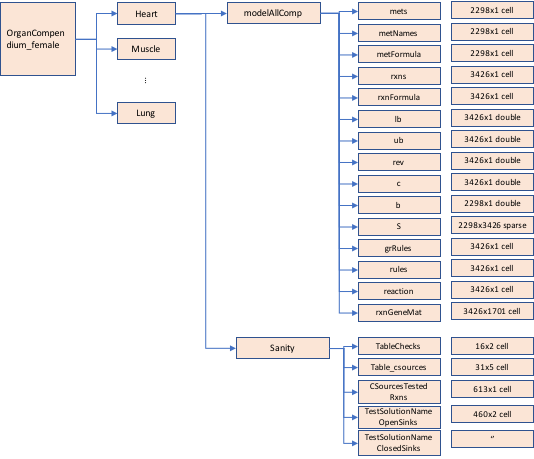

The different organs are stored in the OrganCompendium structure (see Figure above). We then perform basic tests on each organ, such as leak test, metabolic function test, and carbon source ATP yield under aerobic and anaerobic conditions. Please refer to performSanityChecksonRecon.m for more details (or Method Section 1.5). For each organ, a brief report is provided and whether the organ model passed a test or not (see Figure above, Sanity checks, on where to find the report in the OrganCompendium structure).

Recon3* is also used and the same basic tests are performed. The aim here is to allow comparison of the organ's performance with the orginal input model.

The overview of all carbon source yields, including those for Recon 3*, are provided in TableCSources.

Using the organ compendium for a given sex, we then generate statistics for each organ as well as comparison between the sexes. The TableProp contains the information and some plots are generated.

```matlab
clearvars -except male female resultsPath useSolveCobraLPCPLEX computeResults
if ~exist('male', 'var') || ~exist('female', 'var')
    male = loadPSCMfile('Harvey');
    female = loadPSCMfile('Harvetta');
end
```

```matlab
% get organs from the male whole-body metabolic model and performs basic sanity checks.
% Note that single gene deletion analysis is not performed.
if computeResults
    % get organs from the male whole-body metabolic model
    [OrganCompendium_male,TableCSources] = getOrgansFromHarvey(male);
    OrganCompendium_male.sex = 'male';
    save([resultsPath 'OrganAtlas_Harvey'], 'OrganCompendium_male', 'TableCSources')

    % get organs from the female whole-body metabolic model
    [OrganCompendium_female,TableCSources] = getOrgansFromHarvey(female);
    OrganCompendium_female.sex = 'female';
    save([resultsPath 'OrganAtlas_Harvetta'], 'OrganCompendium_female', 'TableCSources')
else
    load OrganAtlas_Harvetta.mat;
    load OrganAtlas_Harvey.mat;
end
```

Compute statistics on each organ in the organ compendium

A more comprehensive comparison output is provided in the file 'Results_StatsOrganComp.mat' that is created at the end of the function getStatsOrganComp.m. TableGRM contains the information displayed in Figure 2. TableProp_female and TableProp_male contains the information summarized in Figure 2 and detailed in Table S14.

```matlab
if computeResults
    % if you wish to display also the violin plots from Figure 2 in the paper please set the following option to 1
    violinPlots = 0;
    [TableProp_female,TableProp_male,TableGRM,TableMetsNum_female,TableMetsNum_male,TableGenes_femaleNum] = getStatsOrganComp(female, male, OrganCompendium_female, OrganCompendium_male,violinPlots);
    %All statistics calculated in the function (getStatsOrganComp) are saved in the file: Results_StatsOrganComp.mat
    save([resultsPath 'Results_StatsOrganComp'], 'TableProp_female', 'TableProp_male', 'TableGRM', 'TableMetsNum_female', 'TableMetsNum_male', 'TableGenes_femaleNum');
else
    load Results_StatsOrganComp;
end
```

Calculate the number of metabolites present in only one organ:

```matlab
sumMetsOrgan = sum(TableMetsNum_female')';
length(find(sumMetsOrgan==1))
```

ans = 212

Calculate the number of metabolites present in two organs:

```matlab
sumMetsOrgan = sum(TableMetsNum_female')';
length(find(sumMetsOrgan==2))
```

ans = 166

Calculate the number of genes present in all organs:

```matlab
sumGenesOrgan = sum(TableGenes_femaleNum')';
HouseHoldGenes = length(find(sumGenesOrgan==size(TableGenes_femaleNum,2)))
```

HouseHoldGenes = 204

Calculate the number of genes present in all organs, excluding the RBC:

```matlab
sumGenesOrgan = sum(TableGenes_femaleNum(:,1:size(TableGenes_femaleNum,2)-1)')';
length(find(sumGenesOrgan==size(TableGenes_femaleNum,2)-1))-HouseHoldGenes
```

ans = 171

Create table with all results from the metabolic functions for all organs: TableMetFuncTests (Table S19).

```matlab
% Create table with all results from the metabolic functions for all male organs:
clear TableMetFuncTests
if ~exist('OrganCompendium_male','var')
    load OrganAtlas_Harvey.mat;
end
Omale = fieldnames(OrganCompendium_male);
cnt = 1;
for i = 1 : length(Omale)
    if ~strcmp('sex',Omale{i}) && ~strcmp('gender',Omale{i}) && ~strcmp('Recon3DHarvey',Omale{i})
        if i == 1
            TableMetFuncTests{2,cnt} = 'Metabolic function names';
            L = length(OrganCompendium_male.(Omale{i}).Sanity.TestSolutionNameOpenSinks(:,1));
            TableMetFuncTests(3:L+2,cnt) =OrganCompendium_male.(Omale{i}).Sanity.TestSolutionNameOpenSinks(:,1);
        end
        TableMetFuncTests{1,cnt+1} = 'male WBM model';
        TableMetFuncTests{2,cnt+1} = Omale{i};
        TableMetFuncTests(3:L+2,cnt+1)= OrganCompendium_male.(Omale{i}).Sanity.TestSolutionNameOpenSinks(:,2);
        cnt = cnt + 1;
    end
end

if ~exist('OrganCompendium_female','var')
    load OrganAtlas_Harvetta.mat;
end
% Create table with all results from the metabolic functions for all female organs:
Ofemale = fieldnames(OrganCompendium_female);
for i = 1 : length(Ofemale)
    if ~strcmp('sex',Ofemale{i}) && ~strcmp('gender',Ofemale{i}) && ~strcmp('Recon3DHarvey',Ofemale{i})
        TableMetFuncTests{1,cnt+1} = 'female WBM model';
        TableMetFuncTests{2,cnt+1} = Ofemale{i};
        TableMetFuncTests(3:L+2,cnt+1)= OrganCompendium_female.(Ofemale{i}).Sanity.TestSolutionNameOpenSinks(:,2);
        cnt = cnt + 1;
    end
end
save([resultsPath 'TableMetFuncTests'],'TableMetFuncTests')
```

## 3.8. Predict metabolite biomarkers for 57 inborn-errors of metabolism (IEMs)

The IEM for which the biomarker(s) are being predicted is displayed at each iteration to help keep track of progress.

```matlab
% uncomment one of the following three:

if computeResults
    modelName = 'Harvey'; % for Harvey
    model = loadPSCMfile(modelName);
    % run the simulations for 57 pre-defined IEMs
    runIEM_HH;
    modelName = 'Harvetta'; % for Harvetta
    model = loadPSCMfile(modelName);
    % run the simulations for 57 pre-defined IEMs
    runIEM_HH;
    modelName = 'Recon3D'; % for Recon3D*
    model = loadPSCMfile(modelName);
    % run the simulations for 57 pre-defined IEMs
    runIEM_HH;
else
    % uncomment one of the following three:
    modelName = 'Harvey'; % for Harvey
    %  modelName = 'Harvetta'; % for Harvetta
    % modelName = 'Recon3D'; % for Recon3D*
    %The simulation results can be found in the Supplemental Table S16 or in the precomputed files.
    switch modelName
        case 'Harvey'
            load Results_IEM_Harvey_1_03
        case 'Harvetta'
            load Results_IEM_Harvetta_1_03
        case 'Recon2D'
            load Results_IEM_Recon3DStar
    end
end
```

## 3.9. Determine BMF for measured BMR data

3.9.1. Identify parameters that affect prediction accuracy

Please note that this is not an exhaustive analysis and other factors can affect the predicted BMR and the agreement with measured BMRs. However, in all cases the predicted BMRs are within the expected range.

Needed personalized physiological data:

- age, weight, height
- measured BMR -for comparison reasons
- measured fat-free body mass (optional)

Considered parameters include:

- adjustment of organ-weights based on measured fat-free body mass
- increasing the amount of atp hydrolysis accounted for in the muscle biomass maintenance reaction

Not considered parameters that may alter the predicted BMR value include

- increasing the amount of atp hydrolysis accounted for in the adipocyte biomass maintenance reaction
- lower bound on brain- and heart atp hydrolysis (DM_atp) for non metabolic processes
- way to estimate the cardiac output (default uses the polynomial suggested by Young et al [62]: CardiacOutput = 9119-exp(9.164-2.91e-2*Wt+3.91e-4*Wt^2-1.91e-6*Wt^3); Wt = weight in kg (optionCardiacOutput = 0))

```matlab
computeResults =0;
if computeResults
    clearvars -except male female resultsPath useSolveCobraLPCPLEX computeResults
    % only female data were available
    female = loadPSCMfile('Harvetta');

    %adjustment for fat free mass
    fatFreeAdj = 1;
    perform_sensi_BMR_all;

    Energy_kcal_femaleBMR2_fatAdj = Energy_kcal_femaleBMR2;
    clearvars -except male female resultsPath useSolveCobraLPCPLEX computeResults Energy_kcal_femaleBMR2_fatAdj

    % only female data were available
    female = loadPSCMfile('Harvetta');

    %no adjustmant for fat free mass
    fatFreeAdj = 0;
    perform_sensi_BMR_all;
    Energy_kcal_femaleBMR2_nofatAdj = Energy_kcal_femaleBMR2;
else
    % results when varying the muscle atp hydrolysis by a factor of 1, 5, and 10
    % in the muscle biomass maintenance reaction as well as when adjusting for fat-free mass as measured in the individuals
    load('Results_sensi_fatAdj.mat')
    Energy_kcal_femaleBMR2_fatAdj = Energy_kcal_femaleBMR2;
    clear Energy_kcal_femaleBMR2
    % results when varying the muscle atp hydrolysis by a factor of 1, 5, and 10 in the muscle biomass maintenance reaction
    % BUT the fat-free mass was not adjusted
    load('Results_sensi_no_fatAdj.mat')
    Energy_kcal_femaleBMR2_nofatAdj = Energy_kcal_femaleBMR2;
    clear Energy_kcal_femaleBMR2
end
```

```matlab
% Display input data
disp(InputDataAll)
```

Columns 1 through 9 'sex' '' 'female' 'female' 'female' 'female' 'female' 'female' 'female' 'age' '' '37' '33' '31' '23' '23' '32' '28' 'Height' '' '161' '158' '163' '165' '163' '158' '163' 'Weight' '' '57.6' '49.5' '55.7' '56.2' '53.2' '49.7' '64.6' 'Fat-free' '' '41' '43.6' '42.9' '41.5' '37.6' '35' '40.8' 'BMR' '' '5.37' '6.19' '5.91' '5.85' '5.06' '5.31' '5.54' Columns 10 through 18 'female' 'female' 'female' 'female' 'female' 'female' 'female' 'female' 'female' '26' '24' '24' '31' '29' '38' '32' '27' '40' '160' '156' '180' '151' '150' '170' '161' '160' '168' '60.6' '59' '71.4' '62.9' '51' '56.4' '74.9' '88.6' '120.1' '43.5' '41.9' '50.2' '43.3' '35.3' '40.7' '44.4' '47.5' '60.6' '5.65' '5.76' '6.4' '5.9' '4.67' '5.86' '6.7' '6.77' '8.2' Columns 19 through 24 'female' 'female' 'female' 'female' 'female' 'female' '39' '36' '38' '26' '37' '39' '161' '164' '162' '160' '169' '165' '83.1' '80.5' '80.3' '79.7' '82.4' '102.1' '47.5' '48.8' '45.9' '44.8' '48.4' '54.2' '6.64' '6.54' '6.42' '6.43' '5.59' '6.73'

The simulation results as well as the measured BMR and the BMR predicted using phenomenological models are stored in BMR_all.

Calculate BMI = weight (kg)/height(m)^2:

```matlab
for i = 3 : 15 % only use the first 15 entries corresponding to normal BMI
    BMI(i,1) = str2num(InputDataAll{4,i})/((str2num(InputDataAll{3,i})/100)^2);
    BMR_measured(i,1) = str2num(InputDataAll{6,i})*0.239006*1000; % in kcal
end
```

Plot BMI against measured BMR (in kcal):

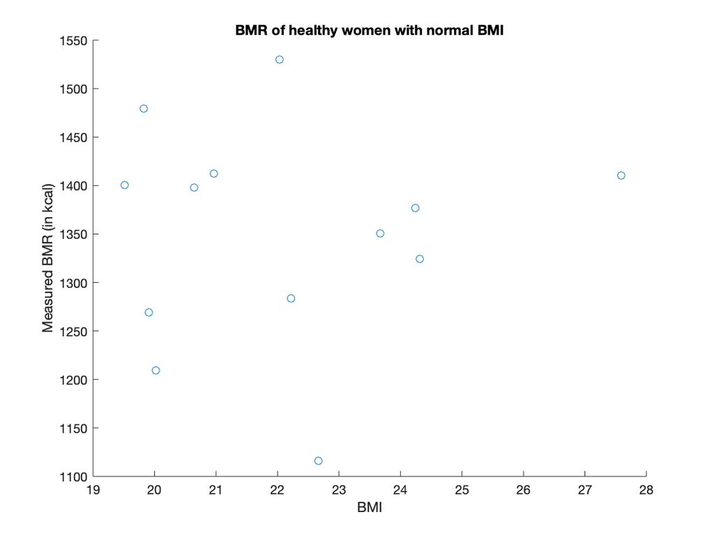

```matlab
figure;
scatter(BMI(3:end),BMR_measured(3:end),'o');
xlabel('BMI');
ylabel('Measured BMR (in kcal)');
title('BMR of healthy women with normal BMI')
```

Store the data of the simulation results (without fat-free mass adjustment).

```matlab
clear BMR_all Rsqr
BMR_all(:,1) = BMR_measured;
BMR_all(1:15,2:4) = Energy_kcal_femaleBMR2_nofatAdj(1:15,1:3); % no fat adjustment
```

The second file contains the results when varying the muscle atp hydrolysis by a factor of 1, 5, and 10 in the muscle biomass maintenance reaction as well as when adjusting for fat-free mass as measured in the individuals.

```matlab
BMR_all(:,5:7) = Energy_kcal_femaleBMR2_fatAdj(:,1:3);
```

Calculate and store the BMR calculated based on the phenomenological data:

```matlab
for i = 3 : 15 % size(InputDataAll,2) - only normal BMI's
    BMR_female_All(:,i) = calculateBMR('female', str2num(InputDataAll{4,i}), str2num(InputDataAll{3,i}), str2num(InputDataAll{2,i}));
end

BMR_all(:,8:10) = BMR_female_All';

% Display all stored data
BMR_all(3:end,:) % first two rows are empty
```

ans = 13×10

10<sup>3</sup> ×

1.2835 1.1172 1.2609 1.4377 1.1163 1.2559 1.4271 1.3308 1.3188 1.2363 1.4794 1.1004 1.2393 1.4031 1.1124 1.3004 1.5500 1.2665 1.2519 1.1565 1.4125 1.1099 1.2540 1.4308 1.1146 1.2765 1.4792 1.3444 1.3334 1.2597 1.3982 1.1112 1.2555 1.4328 1.1127 1.2605 1.4436 1.3902 1.3789 1.3173 1.2094 1.1030 1.2477 1.4195 1.0992 1.2285 1.3799 1.3579 1.3449 1.2748 1.2691 1.1008 1.2400 1.4040 1.0945 1.2056 1.3312 1.2730 1.2581 1.1635 1.3241 1.1187 1.2630 1.4458 1.1164 1.2373 1.3838 1.4435 1.4287 1.3638 1.3504 1.1139 1.2568 1.4389 1.1144 1.2650 1.4551 1.4090 1.3911 1.3150 1.3767 1.1098 1.2545 1.4357 1.1095 1.2532 1.4320 1.3957 1.3725 1.2840 1.5296 1.1075 1.2595 1.4479 1.2653 1.2934 1.5274 1.5587 1.5615 1.5580

Now, we calculate the linear regression (of the form y = a0+a1*x) and display the in silico and phenomenologically predicted BMRs (y axis) against the measured BMRs (x axis).

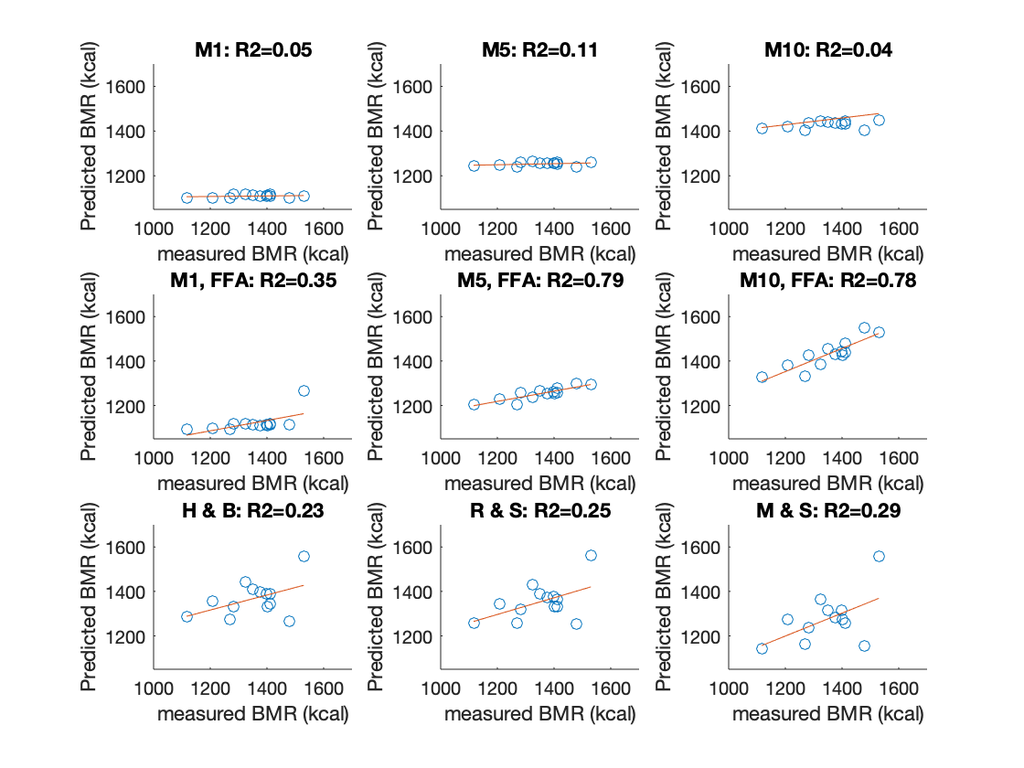

```matlab
figure1 = figure;
for i = 2 : 10
    subplot1 = subplot(3,3,i-1,'Parent',figure1);
    % calculate the linear regression of the form y = a0+a1*x.
    [a0(i-1,1),a1(i-1,1),Rsqr(i-1,1), Residuals] = linearRegression(BMR_all(3:end,1),BMR_all(3:end,i));
    scatter(BMR_all(3:end,1),BMR_all(3:end,i));
    hold on
    plot(BMR_all(3:end,1),(a0(i-1)+BMR_all(3:end,1)*a1(i-1)));
    xlim(subplot1,[1000 1700]);
    ylim(subplot1,[1050 1700]);
    if i==2
        % Muscle atp hydrolysis adjustment in muscle biomass maintenance: factor 1
        title(strcat('M1: R2= ', num2str(round(Rsqr(1),2))));
    elseif i==3
        % Muscle atp hydrolysis adjustment in muscle biomass maintenance: factor 5
        title(strcat('M5: R2= ', num2str(round(Rsqr(2),2))));
    elseif i ==4
        % Muscle atp hydrolysis adjustment in muscle biomass maintenance: factor 10
        title(strcat('M10: R2= ', num2str(round(Rsqr(3),2))))
    elseif i==5
        % Muscle atp hydrolysis adjustment in muscle biomass maintenance: factor 1, fat-free mass adjusted
        title(strcat('M1, FFA: R2= ', num2str(round(Rsqr(4),2))));
    elseif i==6
        % Muscle atp hydrolysis adjustment in muscle biomass maintenance: factor 5, fat-free mass adjusted
        title(strcat('M5, FFA: R2= ', num2str(round(Rsqr(5),2))));
    elseif i ==7
        % Muscle atp hydrolysis adjustment in muscle biomass maintenance: factor 10, fat-free mass adjusted
        title(strcat('M10, FFA: R2= ', num2str(round(Rsqr(6),2))))
    elseif i ==8
        % phenomenological model for BMR estimation based on original Harris & Benedict equations.
        title(strcat('H & B: R2= ', num2str(round(Rsqr(7),2))))
    elseif i ==9
        % phenomenological model for BMR estimation based on original Harris & Benedict equations
        % revised by Roza and Shizgal.
        title(strcat('R & S: R2= ','', num2str(round(Rsqr(8),2))))
    elseif i ==10
        % phenomenological model for BMR estimation based on original Harris & Benedict equations
        % revised by Mifflin and St Jeor.
        title(strcat('M & S: R2= ', num2str(round(Rsqr(9),2))))
    end
    xlabel('measured BMR (kcal)');
    ylabel('Predicted BMR (kcal)');
end
```

As you can see, the best R2 was obtained when the muscle atp hydrolysis in the muscle biomass maintenance was multiplied by the factor 5 and the measured fat-free mass was adjusted for.

3.9.2 Validation of the parameters in an independent data set

As the adjustment for fat-free mass was important, we selected an independent data set that is publically available and has the fat-free mass measured in addition to the BMR. The data set [65] has been derived from 28 athletes from the Modern Pentathlon Rio de Janeiro Federation. The data set included one pre-pubertal individual (female) and two individuals of Asian decent (1 female, 1 male), which we excluded from the comparison as the phenomenoligcal models used to derive the physiological constraints for Harvetta and Harvey do not capture these populations well. The considered data contains 9 females and 16 males. The mean age was 14.7 years (SD 2.3) for females and 14.8 years (SD 1.7) for males. The mean height was 159.3 cm (SD 9.9) for females and 169.3 cm (SD 8.5) for males. The mean weight was 50.5 kg (SD 8.9) for females and 57.3 kg (SD 8.6) for males. The fat-free body mass was 39.15 kg (SD 9.6) for females and 48.6 kg (SD 7.8) for males. The mean BMI was consequently 19.7 (SD 1.5) for females and 19.9 (SD 1.5) for males. The measured BMR was 1353.7 kcal (SD 143.3) for females and 1564.2 kcal (SD 208.3) for males.

We scaled the atp hydrolysis coefficients of the muscle biomass maintenance reaction in Harvey and Harvetta by the factor 5 (as determined in 3.9.1) and adjusted the fat-free body mass according to the measurements.

The simulation can be repeated using this script:

```matlab
% Please set to 1 if you want to repeat the simulation. Note that this may take some time.
if computeResults
    female = loadPSCMfile('Harvetta');
    male = loadPSCMfile('Harvey');

    perform_BMR_newData;

    %save Results_sensi2_2018_12_14
    save([resultsPath 'Results_BMR_newData'],'BMR_male_20', 'Energy_kcal_maleBMR2', 'Energy_kcal_maleBMR2_origStatText','BMR_female_20', 'Energy_kcal_femaleBMR2', 'Energy_kcal_femaleBMR2_origStatText')
else
    %load the (pre-)computed results:
    %load Results_sensi2_2018_12_14;
    load Results_BMR_newData
end
```

This time, the females and males are present in the entire data set.

```matlab
InputDataAll ={ 'sex'	''	'male'	'female'	'female'	'female'	'female'	'female'	'male'	'female'	'male'	'male'	'male'	'female'	'male'	'male'	'male'	'male'	'male'	'female'	'female'	'female'	'male'	'male'	'male'	'female'	'male'	'male'	'male'	'male'
    'age'	''	'15'	'14'	'12'	'18'	'16'	'15'	'17'	'11'	'13'	'14'	'16'	'16'	'12'	'15'	'16'	'18'	'13'	'11'	'12'	'17'	'12'	'15'	'17'	'12'	'15'	'15'	'14'	'15'
    'Height'	''	'168'	'164'	'152'	'162'	'166'	'173'	'172'	'161'	'164'	'165'	'170'	'156'	'172'	'175'	'177'	'173'	'161'	'155'	'157'	'165'	'150'	'174'	'175'	'139'	'184'	'162'	'159.5'	'177'
    'Weight'	''	'60.8'	'56.8'	'40.2'	'53.2'	'54.1'	'62.9'	'64.4'	'56.2'	'47.9'	'52.8'	'65.6'	'49.9'	'58'	'69.1'	'64.8'	'63.5'	'48'	'50.4'	'44.3'	'58'	'40.1'	'61.2'	'64.6'	'35.4'	'65.8'	'47.4'	'48.2'	'59.6'
    'Fat-free'	''	'51.66'	'40.08'	'30.08'	'43.71'	'42.88'	'53.44'	'58.18'	'36.4'	'41.4'	'47'	'55.91'	'39.52'	'48.23'	'59.75'	'56'	'53.86'	'42'	'33.75'	'37.31'	'45.31'	'33.62'	'53.22'	'56.62'	'20'	'49'	'38.56'	'39'	'50'
    'BMI'	''	'21.54'	'21.12'	'17.4'	'20.27'	'19.63'	'21.02'	'21.77'	'21.68'	'17.81'	'19.39'	'22.7'	'20.5'	'19.61'	'22.56'	'20.68'	'21.22'	'18.52'	'20.98'	'17.97'	'21.3'	'17.82'	'20.21'	'21.09'	'18.32'	'19.44'	'18.06'	'18.95'	'19.02'
    'BMR'	''	'1661.16'	'1414.97'	'1282.42'	'1489.45'	'1277.24'	'1582.33'	'1515.13'	'1495.3'	'1775.51'	'1576.21'	'1476.97'	'1271.78'	'1551.96'	'2039.63'	'1808.9'	'1537.86'	'1457.89'	'1243.59'	'1443.9'	'1318.07'	'1249.74'	'1537.93'	'1633.33'	'1103.2'	'1508.41'	'1393.85'	'1167.48'	'1612.75'
    'Ethnicity'	''	'2'	'2'	'1'	'2'	'2'	'2'	'1'	'3'	'1'	'1'	'3'	'1'	'1'	'1'	'2'	'2'	'1'	'1'	'2'	'1'	'2'	'1'	'1'	'1'	'1'	'1'	'2'	'2'
    'Sexual Maturation'	''	'2'	'2'	'2'	'3'	'2'	'2'	'2'	'2'	'2'	'2'	'2'	'2'	'2'	'2'	'3'	'3'	'2'	'1'	'2'	'2'	'2'	'2'	'2'	'2'	'3'	'2'	'2'	'3'
    };
```

We will first sort the results. Females will be stored in BMR_all_female and males in BMR_all_males.

Note that three female models were infeasible, i.e., no solution could be calculated. These females have in common that they have a very low BMI. Consequently, only six females were compared with the measured BMR values.

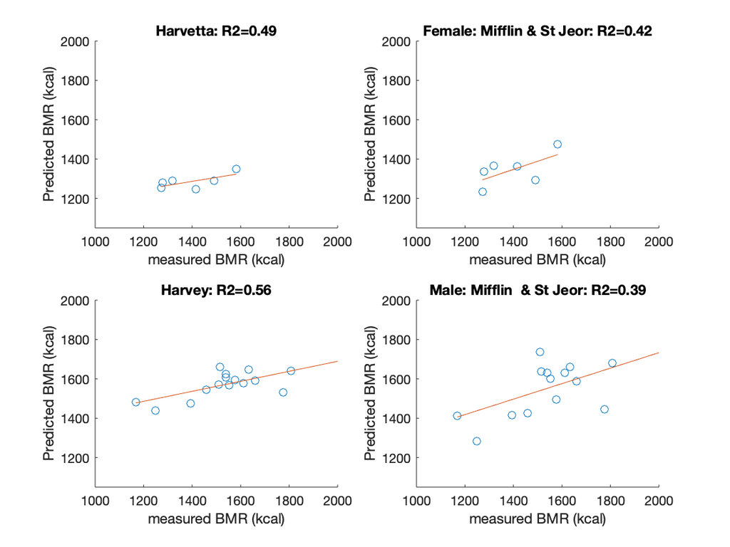

```matlab
m=1; f=1;
clear BMR_all_male BMR_all_female
for i = 3 : size(InputDataAll,2)
    if strcmp(InputDataAll{1,i},'male')
        if str2num(InputDataAll{8,i})~=3 && str2num(InputDataAll{9,i})~=1 % exclude individuals of Asian decent (3) or pre-puberty(1)
            BMR_all_male(m,1) = str2num(InputDataAll{7,i});
            BMR_all_male(m,2) = Energy_kcal_maleBMR2(i);
            BMR_all_male(m,3) = BMR_male_20(3,i);
            m=m+1;
        end

    elseif strcmp(InputDataAll{1,i},'female')

        if Energy_kcal_femaleBMR2(i,1)>0 && Energy_kcal_femaleBMR2(i,1)<3000 % exclude infeasible models

            if  str2num(InputDataAll{8,i})~=3 && str2num(InputDataAll{9,i})~=1 % exclude individuals of Asian decent (3) or pre-puberty(1)
                BMR_all_female(f,1) = str2num(InputDataAll{7,i});
                BMR_all_female(f,2) = Energy_kcal_femaleBMR2(i,1);
                BMR_all_female(f,3) = BMR_female_20(3,i);
                f=f+1;
            end
        end
    end
end

figure1 =figure;

subplot1 = subplot(2,2,1,'Parent',figure1);
[a0,a1,Rsqr_female(1,1), Residuals] = linearRegression(BMR_all_female(1:end,1),BMR_all_female(1:end,2));
scatter(BMR_all_female(1:end,1),BMR_all_female(1:end,2));
hold on
plot(BMR_all_female(1:end,1),(a0+BMR_all_female(1:end,1)*a1));
title(strcat('Harvetta: R2= ', num2str(round(Rsqr_female(1),2))));
xlim(subplot1,[1000 2000]);
ylim(subplot1,[1050 2000]);
xlabel('measured BMR (kcal)');
ylabel('Predicted BMR (kcal)');

subplot1 = subplot(2,2,2,'Parent',figure1);
[a0,a1,Rsqr_female(1,2)] = linearRegression(BMR_all_female(1:end,1),BMR_all_female(1:end,3));
scatter(BMR_all_female(1:end,1),BMR_all_female(1:end,3));
hold on
plot(BMR_all_female(1:end,1),(a0+BMR_all_female(1:end,1)*a1));
title(strcat('Female: Mifflin & St Jeor: R2= ', num2str(round(Rsqr_female(2),2))));
xlim(subplot1,[1000 2000]);
ylim(subplot1,[1050 2000]);
xlabel('measured BMR (kcal)');
ylabel('Predicted BMR (kcal)');

subplot1 = subplot(2,2,3,'Parent',figure1);
[a0,a1,Rsq_male(1,1)] = linearRegression(BMR_all_male(1:end,1),BMR_all_male(1:end,2));
scatter(BMR_all_male(1:end,1),BMR_all_male(1:end,2));
hold on
plot(BMR_all_male(1:end,1),(a0+BMR_all_male(1:end,1)*a1));
title(strcat('Harvey: R2= ', num2str(round(Rsq_male(1),2))));
xlim(subplot1,[1000 2000]);
ylim(subplot1,[1050 2000]);
xlabel('measured BMR (kcal)');
ylabel('Predicted BMR (kcal)');

subplot1 = subplot(2,2,4,'Parent',figure1);
[a0,a1,Rsq_male(1,2)] = linearRegression(BMR_all_male(1:end,1),BMR_all_male(1:end,3));
scatter(BMR_all_male(1:end,1),BMR_all_male(1:end,3));
hold on
plot(BMR_all_male(1:end,1),(a0+BMR_all_male(1:end,1)*a1))
title(strcat('Male: Mifflin  & St Jeor: R2= ', num2str(round(Rsq_male(2),2))));
xlim(subplot1,[1000 2000]);
ylim(subplot1,[1050 2000]);
xlabel('measured BMR (kcal)');
ylabel('Predicted BMR (kcal)');
```

## 3.10. Host-microbiome modeling

Note that for practical purposes, we only show the procedure for one host-microbiome model.

3.10.1 . Generate personalized host-microbiome model (modelHM)

Note that for practical purposes, we only show the procedure for one host-microbiome model.

The microbiome models were obtained from a previous study (57, 63). Briefly, we obtained from human microbiome project (http://hmpdacc.org/) for 149 gastrointestinal tract samples the identified strain names and their relative abundance as well as associated meta-data (sex, weight, height, and heart rate). These samples were originally obtained from healthy US individuals aged 18-45 . We mapped the strain names manually onto the AGORA microbial genome-scale reconstruction collections. All unmatched strains were ignored.

Using the presence and absence information for each sample, we generated the corresponding microbiota models. Therefore, we used the Cobra Toolbox (0) function: mergeTwoModels. We added one by one the identified microbial model to the microbiota model by joining them on the level of shared exchange metabolites ([e]) and exchange reactions. Note that this compartment will be renamed to [luM] in 3.10.1.3. Once the microbiota model was constructed, we added a community biomass reaction to the model, which is the linear combination of the biomass reactions of all microbes present in the microbiota model. The stoichiometric coefficients for each microbe biomass reaction in this community microbiota biomass reaction corresponds to the relative abundance found for the strain in the given sample. To enforce that flux througn a microbial reaction only occurs when its biomass reaction has a non-zero value, we included so called coupling constraints. Effectively, these coupling constraints enforce the flux through all metabolic and transport reactions to be proportional to an organism’s biomass objective function (58).

3.10.1.1. Load whole body and microbiome models

```matlab
if ~exist('male', 'var') || ~exist('female', 'var')
    male = loadPSCMfile('Harvey');
    female = loadPSCMfile('Harvetta');
end

files = {'SRS011239'};
% load microbiome model
load(strcat('microbiota_model_samp_',files{1},'.mat'));
```

This is how the microbiota_model looks like. The first horizontal line corresponds to the exchange metabolites that are shared between the different microbial models. The first seemingly diagonal line corresponds to the microbes. The second diagonal "line" corresponds to the coupling constraints,

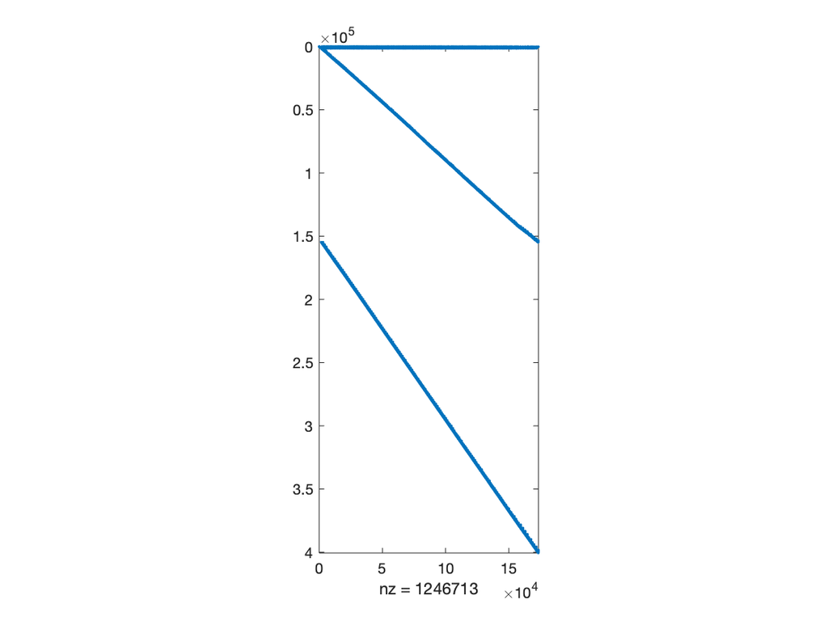

```matlab
figure;
spy([microbiota_model.A])
```

Number of rows (metabolites) and number of reactions in this microbiota model:

```matlab
size(microbiota_model.S)
```

ans = 1×2

154801 173353

Number of non-zero entries:

```matlab
nnz(microbiota_model.S)
```

ans = 755091

```matlab
clear structure;
```

3.10.1.2. Alternatively the microbiome models can be generated using the Microbiome Toolbox

```matlab
if 0
    % path where to save results
    mkdir('microbiomeModels');
    resPath=(strcat(currentDir,'/microbiomeModels'));
    % path to where the COBRA Toolbox is located
    global CBTDIR
    toolboxPath=CBTDIR;
    % path to and name of the file with dietary information.
    dietFilePath=[CBTDIR filesep 'papers' filesep '2018_microbiomeModelingToolbox' filesep 'resource' filesep 'AverageEuropeanDiet'];
    % path to and name of the file with abundance information.
    abunFilePath=[CBTDIR filesep 'papers' filesep '2018_microbiomeModelingToolbox' filesep 'examples' filesep 'normCoverage.csv'];
    indInfoFilePath='';
    % name of objective function of organisms
    objre={'EX_biomass(e)'};
    %the output is vectorized picture, change to '-dpng' for .png
    figForm = '-depsc';
    % number of cores dedicated for parallelization
    numWorkers = 12;
    % autofix for names mismatch
    autoFix = 1;
    % if outputs in open formats should be produced for each section (1=T)
    compMod = 0;
    % if documentations on patient health status is provided (0 not 1 yes)
    patStat = 0;
    % to enable also rich diet simulations
    rDiet = 0;
    % if if to use an external solver and save models with diet
    extSolve = 0;
    % the type of FVA function to use to solve
    fvaType = 1;
    % To tourn off the autorun to be able to manually execute each part of the pipeline.
    autorun=1;
    %END OF REQUIRED INPUT VARIABLES
    %
    %PIPELINE LAUNCHER
    [init, modelPath, toolboxPath, resPath, dietFilePath, abunFilePath, indInfoFilePath, objre, figForm, numWorkers, autoFix, compMod, rDiet, extSolve, fvaType, autorun] = initMgPipe(modPath, toolboxPath, resPath, dietFilePath, abunFilePath, indInfoFilePath, objre, figForm, numWorkers, autoFix, compMod, rDiet, extSolve, fvaType, autorun);
end
```

3.10.1.2. Load the metadata from the HMP study

This file contains information on sex, heart rate (pulse), weight, height - which we will use for the personalization of the whole-body metabolic models as well as information on blood pressure, dietary habits (meat vs. vegetarian), and race. We did not use these latter features for the personalization of the WBM models.

We decided not to distinguish between vegetarian and meat eaters as the number of vegetarians was very small.

```matlab
% load in HMP meta-data

load InputDataHMP_fromxlsx;
% Example on how the input data look like:
InputData(:,1:3)
```

ans = 8×3 cell

|  | 1 | 2 | 3 |
| --- | --- | --- | --- |
| 1 | 'ID' | ' ' | 'SRS011061' |
| 2 | 'sex' | ' ' | 'Female' |
| 3 | 'Weight' | 'kg' | 84 |
| 4 | 'Height' | 'cm' | 170.2000 |
| 5 | 'BMI' | ' ' | 29 |
| 6 | 'Age' | ' ' | 30 |
| 7 | 'Diet' | ' ' | '01-Meat/fish/poultry at least three days per week' |
| 8 | 'HeartRate' | ' ' | 79 |

```matlab
% 1. match filename with ID
ID = strmatch(files{1},InputData(1,:));
% 2. Sex
G = strmatch('sex',InputData(:,1));
sex = lower(InputData{G,ID});

% get an overview on the input data
a = 1;
b = 1;
for i = 3:size(InputData,2)
    if strcmp(lower(InputData(2,i)),'female')
        IP_female(a,:)=[InputData{3,i} InputData{4,i} InputData{6,i} InputData{8,i}];
        a = a + 1;
    elseif strcmp(lower(InputData(2,i)),'male')
        IP_male(b,:)=[InputData{3,i} InputData{4,i} InputData{6,i} InputData{8,i}];
        b = b + 1;
    end
end

Table_Input_Stats(1,:) = {'' 'female' 'male'};
Table_Input_Stats(2,:) = {'n' num2str(size(IP_female,1)) num2str(size(IP_male,1))};
Table_Input_Stats(3,:) = {'av(weight)' num2str(mean(IP_female(:,1))) num2str(mean(IP_male(:,1)))};
Table_Input_Stats(4,:) = {'std(weight)' num2str(std(IP_female(:,1))) num2str(std(IP_male(:,1)))};
Table_Input_Stats(5,:) = {'av(height)' num2str(mean(IP_female(:,2))) num2str(mean(IP_male(:,2)))};
Table_Input_Stats(6,:) = {'std(height)' num2str(std(IP_female(:,2))) num2str(std(IP_male(:,2)))};
Table_Input_Stats(7,:) = {'av(age)' num2str(mean(IP_female(:,3))) num2str(mean(IP_male(:,3)))};
Table_Input_Stats(8,:) = {'std(age)' num2str(std(IP_female(:,3))) num2str(std(IP_male(:,3)))};
Table_Input_Stats(9,:) = {'av(HR)' num2str(mean(IP_female(:,4))) num2str(mean(IP_male(:,4)))};
Table_Input_Stats(10,:) = {'std(HR)' num2str(std(IP_female(:,4))) num2str(std(IP_male(:,4)))};

Table_Input_Stats
```

Table_Input_Stats = 10×3 cell array

'' 'female' 'male'  
'n' '66' '83'  
'av(weight)' '65.5242' '80.3458'  
'std(weight)' '13.1465' '11.2721'  
'av(height)' '163.1091' '178.6313'  
'std(height)' '6.6301' '7.0985'  
'av(age)' '25.8636' '27.0361'  
'std(age)' '4.9237' '5.0035'  
'av(HR)' '75.2576' '71.5904'  
'std(HR)' '11.129' '11.6358'

3.10.1.3. Combine the whole-body metabolic model with the microbiome model

As a next step, we join the whole-body metabolic model with the microbiome model. The whole-body metabolic model contains a compartment [luLI] representing the large intestinal lumen. It is connected to the lumen of the small intestine ([luSI]), from where dietary components and the output of the bile duct, come to the luLI. Metabolites in the luLI are either taken up by colonocytes or transported to the feces ([fe]), which is then excreted via exchange reactions (Excretion_metabolite[fe]: 1 metabolite[fe] -->) .

Similarly, the microbiome model contains a luminal compartment ([luM]), into which each microbe can excrete or take up metabolites. Note that each microbe is an independent functional unit within this community model, meaning that the metabolic models have been joined while maintaining their own metabolic networks. The microbial interactions occur through the luminal compartment.

We join the whole-body metabolic model with the microbiome model by connecting both stoichiometric matrices and adding transport reactions between [luM] and [luLI] to the joint model, called modelHM. Any exchange reactions present in the microbiome model are removed as metabolites are provided and eliminated now through these new transport reactions and subsequently, through the reactions present in the whole-body metabolic model (e.g., excretion reactions). To represent the excretion of microbial mass, which is ultimately measured by the metagenomic tools, we add a transport reaction of the community-biomass reaction from [luM] to [luLI], from [luLI] to [fe], and its excretion via an excretion reaction.

Assumptions:

- We assumed that all identified microbes in a metagenomic sample were present in the large intestine, and not in the small intestine.
- We do not account for metabolite release in the luLI due to cell lysis.
- Due to the steady-state assumption, we cannot place concentration constraints on the microbes (abundance of each strain). However, most microbiome studies do not measure or predict the absolute microbial abundance, but instead infer the relative microbial abundance from the fecal matter. The relative abundance in the feces thus corresponds to living or dead cells, which under steady state have to be replenished in the colon through microbial growth. By placing constraints on the microbial community biomass fecal excretion reaction, we mimic precisely that. Hence, we do not need to know the absolute abundance of each strain.
- If not stated differently, we assume that the whole-body metabolic model has fecal excretion once a day (by setting the bounds on the corresponding exchange reaction to 1).
- For consistency with the coupling constraints used in the whole-body metabolic model, we used a coupling constraints of 20000 also for coupling microbial reactions with their respective biomass reaction.

```matlab
if computeResults
    % create HM model
    if strcmp(sex,'male')
        modelHM = combineHarveyMicrotiota(male,microbiota_model);
    elseif strcmp(sex,'female')
        modelHM = combineHarveyMicrotiota(female,microbiota_model);
    end
    modelHM.sex = sex;
    modelHM.ID = InputData(1,ID);
    save([resultsPath 'modelHM_' sex],'modelHM')
else
    load(['modelHM_' sex])
end
```

Let's have look at the models that we just created. Note that all non-zero entries in the stoichiometric matrix are shown as blue dots.

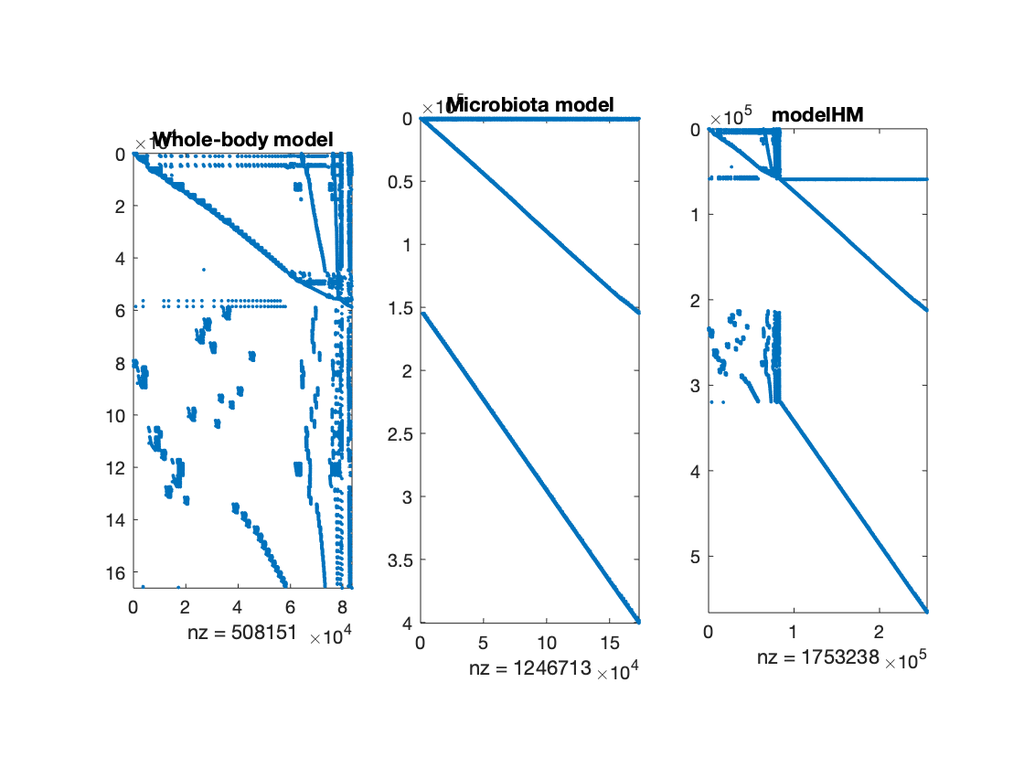

```matlab
figure;
subplot(1,3,1)
if strcmp(sex,'male')
    if useSolveCobraLPCPLEX
        spy(male.A)
    else
        spy([male.S;male.C])
    end
elseif strcmp(sex,'female')
    if useSolveCobraLPCPLEX
        spy(female.A)
    else
        spy([female.S;female.C])
    end
end
title('Whole-body model')
subplot(1,3,2)
if isfield(microbiota_model,'C')
    spy([microbiota_model.S;microbiota_model.C])
else
    spy(microbiota_model.A);
end
title('Microbiota model')
subplot(1,3,3)
spy([modelHM.S;modelHM.C])
title('modelHM')
```

3.10.1.4. Personalize the host-microbiota model

Note that the personalization described in the following section does not require the presence of the microbiota but can also be done on the vanilla male and female model.

Based on the metadata, we personalize the IndividualParameters.

Assumptions:

- We assume that the heart rate refers to the resting (sitting up) heart rate.

Blood volume estimation

The blood volume (BV) of the personalized model is calculated based on the Nadler's equations (59):

- Male: BV = 0.3669 * Ht^3 + 0.03219 * Wt + 0.6041
- Female: BV = 0.3561 * Ht^3 + 0.03308 * Wt + 0.1833
- Note: Ht = height in meters, Wt = body weight in kg, BV = blood volume in ml

Cardiac output estimation

We implemented different ways of estimating the cardiac output (CO). The resulting CO is given in ml/min

- Based on heart rate and stroke volume: CardiacOutput = HeartRate * StrokeVolume. (optionCardiacOutput = 1)
- Assume that cardiac output = blood volume. (optionCardiacOutput = 2)
- Based on the polynomial suggested by Youndg et al [http://www.ams.sunysb.edu/~hahn/psfile/pap_obesity.pdf]: CardiacOutput = 9119-exp(9.164-2.91e-2*Wt+3.91e-4*Wt^2-1.91e-6*Wt^3); Wt = weight in kg (optionCardiacOutput = 0)
- Based on Fick's principle, which requires that the oxygen consumption rate is known: VO_2 = (CO* C_a) - (CO *C_v); where CO = Cardiac Output, Ca = Oxygen concentration of arterial blood and Cv = Oxygen concentration of mixed venous blood. We assume that C_a is 200 ml O2/L and C_v is 150 ml O2/L. (optionCardiacOutput = 3)
- Based on Fick's principle, while estimating the VO_2 based on the body surface area (BSA): We use the Du Bois formula (60, 61): BSA=0.007184 * Wt^0.425* Ht^0.725; Wt = weight in kg; Ht in cm; (optionCardiacOutput = 4)

In this study, we applied optionCardiacOutput = 1 using the default stroke volume of SV = 80 ml/beat.

```matlab
% load standard physiological data, depending on the sex
sex = 'female';
standardPhysiolDefaultParameters;
% set personalized constraints as given by the input data
Input = [InputData(:,1) InputData(:,2) InputData(:,ID)]
```

Input = 8×3 cell

|  | 1 | 2 | 3 |
| --- | --- | --- | --- |
| 1 | 'ID' | ' ' | 'SRS011239' |
| 2 | 'sex' | ' ' | 'Female' |
| 3 | 'Weight' | 'kg' | 71.5000 |
| 4 | 'Height' | 'cm' | 171.2000 |
| 5 | 'BMI' | ' ' | 24 |
| 6 | 'Age' | ' ' | 27 |
| 7 | 'Diet' | ' ' | '01-Meat/fish/poultry at least three days per week' |
| 8 | 'HeartRate' | ' ' | 77 |

```matlab
[modelHM,IndividualParametersPersonalized] = individualizedLabReport(modelHM,IndividualParameters, Input);
IndividualParametersPersonalized
```

IndividualParametersPersonalized = struct with fields:

OrgansWeights: {53×3 cell} ID: {'SRS011239'} bodyWeight: 71.5000 Height: 171.2000 sex: 'female' HeartRate: 77 StrokeVolume: 80 CardiacOutput: 6160 Hematocrit: 0.4000 MConUrCreatinineMax: 1.2000 MConUrCreatinineMin: 0.5000 MConDefaultBc: 20 MConDefaultCSF: 20 MConDefaultUrMax: 20 MConDefaultUrMin: 0 CSFFlowRate: 0.3500 CSFBloodFlowRate: 0.5200 UrFlowRate: 2000 GlomerularFiltrationRate: 90 bloodFlowData: {32×8 cell} bloodFlowRow: 2 bloodFlowPercCol: [4 6] bloodFlowOrganCol: 1 age: 27 BloodVolume: 4.3354e+03 CardiacOutput_Note: 'Calculated from default StrokeVolume and heart rate'

```matlab
modelHM.IndividualParametersPersonalized = IndividualParametersPersonalized;
```

3.10.1.5. Calculate the organ percentage based on weight and height

We update the stoichiometric coefficients of whole-body biomass reaction based on a person's estimated body composition estimated using published polynomials, as proposed by (62). We use the polynomials to compute thus the organ weight fraction and adjust all other organs, for which no data is available, accordingly, while maintaining the numbers provided for the reference man/woman.

Male:

- Brain: 1.41e-01 + (-5.54e-06 * Wt) + 9.30e-11 * Wt^2 + (-6.83e-16 * Wt^3) + 1.80e-21 * Wt^4 + 0.0 * Wt^5;
- Heart: 6.32e-03 + (-1.67e-08 * Wt) + 0.0 * Wt^2 + 0.0 * Wt^3 + 0.0 * Wt^4 + 0.0 * Wt^5;
- Kidney: 7.26e-03 + (-6.69e-08 * Wt) + 3.33e-13 * Wt^2 + 0.0 * Wt^3 + 0.0 * Wt^4 + 0.0 * Wt^5;
- Liver: 4.25e-02 + (-1.01e-06 * Wt) + 1.99e-11 * Wt^2 + (-1.66e-16 * Wt^3) + 4.83e-22 * Wt^4 + 0.0 * Wt^5;
- Lungs: 1.86e-02 + (-4.55e-08 * Wt) + 0.0 * Wt^2 + 0.0 * Wt^3 + 0.0 * Wt^4 + 0.0 * Wt^5;
- Spleen: 3.12e-03 + (-5.57e-09 * Wt) + 0.0 * Wt^2 + 0.0 * Wt^3 + 0.0 * Wt^4 + 0.0 * Wt^5;
- Agland: 8.04e-04 + (-1.98e-08 * Wt) + 2.01e-13 * Wt^2 + (-6.11e-19 * Wt^3) + 0.0 * Wt^4 + 0.0 * Wt^5;
- Pancreas: 1.48e-03 + 0.0 * Wt + 0.0 * Wt^2 + 0.0 * Wt^3 + 0.0 * Wt^4 + 0.0 * Wt^5;
- Thymus: 3.70e-03 + (-1.05e-07 * Wt) + 7.94e-13 * Wt^2 + 0.0 * Wt^3 + 0.0 * Wt^4 + 0.0 * Wt^5;
- Thyroidgland: 2.42e-04 + 0.0 * Wt + 0.0 * Wt^2 + 0.0 * Wt^3 + 0.0 * Wt^4 + 0.0 * Wt^5;
- Adipocytes: 1.61e-01 + (-3.59e-06 * Wt) + 8.28e-11 * Wt^2 + (-3.57e-16 * Wt^3) + 4.73e-22 * Wt^4 + 0.0 * Wt^5;
- Muscle: 9.68e-02 + (-3.32e-06 * Wt) + 1.83e-10 * Wt^2 + (-1.24e-15 * Wt^3) + 0.0 * Wt^4 + 0.0 * Wt^5;
- Skin: 1.03e-01 + (-2.56e-06 * Wt) + 3.68e-11 * Wt^2 + (-2.58e-16 * Wt^3) + 8.62e-22 * Wt^4 + (-1.10e-27 * Wt^5);
- Blood: 8.97e-02 + (-3.50e-07 * Wt) + 6.54e-13 * Wt^2 + 0.0 * Wt^3 + 0.0 * Wt^4 + 0.0 * Wt^5;

Female:

- Brain: 1.12e-01 + (-3.33e-06 * Wt) + 4.30e-11 * Wt^2 + (-2.45e-16 * Wt^3) + 5.03e-22 * Wt^4 + 0.0 * Wt^5;
- Heart: 5.40e-03 + (-1.07e-08 * Wt) + 0.0 * Wt^2 + 0.0 * Wt^3 + 0.0 * Wt^4 + 0.0 * Wt^5;
- Kidney: 7.56e-03 + (-5.58e-08 * Wt) + 1.54e-13 * Wt^2 + 0.0 * Wt^3 + 0.0 * Wt^4 + 0.0 * Wt^5;
- Liver: 3.34e-02 + (-1.89e-07 * Wt) + 5.34e-13 * Wt^2 + 0.0 * Wt^3 + 0.0 * Wt^4 + 0.0 * Wt^5;
- Lungs: 1.89e-02 + (-5.94e-08 * Wt) + 0.0 * Wt^2 + 0.0 * Wt^3 + 0.0 * Wt^4 + 0.0 * Wt^5;
- Spleen: 2.96e-03 + (-7.72e-09 * Wt) + 0.0 * Wt^2 + 0.0 * Wt^3 + 0.0 * Wt^4 + 0.0 * Wt^5;
- Agland: 8.04e-04 + (-1.98e-08 * Wt) + 2.01e-13 * Wt^2 + (-6.11e-19 * Wt^3) + 0.0 * Wt^4 + 0.0 * Wt^5;
- Pancreas: 1.48e-03 + 0.0 * Wt + 0.0 * Wt^2 + 0.0 * Wt^3 + 0.0 * Wt^4 + 0.0 * Wt^5;
- Thymus: 3.70e-03 + (-1.05e-07 * Wt) + 7.94e-13 * Wt^2 + 0.0 * Wt^3 + 0.0 * Wt^4 + 0.0 * Wt^5;
- Thyroidgland: 2.42e-04 + 0.0 * Wt + 0.0 * Wt^2 + 0.0 * Wt^3 + 0.0 * Wt^4 + 0.0 * Wt^5;
- Adipocytes: 1.84e-01 + (-6.86e-06 * Wt) + 2.46e-10 * Wt^2 + (-2.11e-15 * Wt^3) + 7.58e-21 * Wt^4 + (-9.94e-27 * Wt^5);
- Muscle: 3.65e-02 + 7.91e-06 * Wt + (-5.74e-11 * Wt^2) + 0.0 * Wt^3 + 0.0 * Wt^4 + 0.0 * Wt^5;
- Skin: 9.81e-02 + (-2.28e-06 * Wt) + 2.74e-11 * Wt^2 + (-1.58e-16 * Wt^3) + 4.30e-22 * Wt^4 + (-4.43e-28 * Wt^5);
- Blood: 8.97e-02 + (-3.50e-07 * Wt) + 6.54e-13 * Wt^2 + 0.0 * Wt^3 + 0.0 * Wt^4 + 0.0 * Wt^5;
- Breast: 0.01 + 0.0 * Wt + 0.0 * Wt^2 + 0.0 * Wt^3 + 0.0 * Wt^4 + 0.0 * Wt^5;

Blood cells

Use the estimated blood weight to determine the fraction of the different blood cells.

- White blood cells (WBCs) make about 1% of blood (21) for numbers: WBCWeight = 0.01*BloodWeight;
- Lymphocytes represnt about 15-40% of the white blood cells (21) for numbers. We assumed 30% of WBC weight: LympWeight = 0.3*WBCWeight;
- Bcells represent about 9% of the lymphocytes (23): BcellsWeight = 0.09*LympWeight;
- CD4Tcells represent 45-75% of the lymphocytes or 4 – 20% of leukocyte (24). We assumed 15% of leukocytes: CD4TcellsWeight = 0.15*WBCWeight;
- Human and mouse NK cells constitute approximately 15% of all circulating lymphocytes (21) for numbers]: NkcellsWeight = 0.15*LympWeight;
- Monocytes represent about 2-8% of the peripheral WBCs (24). We assumed 5%: MonocyteWeight = 0.05*WBCWeight;
- There are about 150,000 to 400,000 platelets/mm3; 1mm3 = 1e-6 l; 10 pg per platelet (wet weight) (25) for weight; (26). We assumed 400k platelets/mm3; corresponding to 4g platelets/l blood; PlateletWeight= 4*BloodVolume/1000;
- The normal range of red blood cells (RBCs) in men is approximately 4.7 to 6.1 million cells/ul. The normal range in women range from 4.2 to 5.4 million cells/ul, according to National Institutes of Health data. 27 pg dry weight of one RBC (27) for numbers; (28) for dry weight;]. We assumed 70% water in RBCs, hence 90 pg/RBC corresponding to 495g/l: RBCWeigth = 495*BloodVolume/1000; %495g/l

We took the computed cardiac output to estimate the blood volume for the calculations of the blood cell fractions.

```matlab
[listOrgan,OrganWeight,OrganWeightFract] = calcOrganFract(modelHM,IndividualParametersPersonalized);
% adjust whole body maintenance reaction based on new organ weight
% fractions
[modelHM] = adjustWholeBodyRxnCoeff(modelHM, listOrgan, OrganWeightFract);
```

Please note that at this stage, we still assume the same blood flow distribution for each organ as in the reference man and woman (at rest).

```matlab
% apply HMDB metabolomic data based on personalized individual parameters
modelHM = physiologicalConstraintsHMDBbased(modelHM,IndividualParametersPersonalized);
```

Set simulation specific constraints, store personalized data, and enforce that the whole-body metabolic model excretes feces once a day.

```matlab
% set some more constraints
modelHM = setSimulationConstraints(modelHM);
modelHM.status = 'personalized microbiota, personalized Harvey/Harvetta';
modelHM.InputData = [InputData(:,1) InputData(:,2) InputData(:,ID)];
% require Brain_dm_atp_c_ to be at least 5000 mmol/day/person
modelHM = changeRxnBounds(modelHM,'Brain_DM_atp_c_',5500,'l');
modelHM = changeRxnBounds(modelHM,'Heart_DM_atp_c_',6000,'l');
% set microbial excretion constraint
modelHM.lb(find(ismember(modelHM.rxns,...
    'Excretion_EX_microbiota_LI_biomass[fe]')))=1; %
modelHM.ub(find(ismember(modelHM.rxns,...
    'Excretion_EX_microbiota_LI_biomass[fe]')))=1; %
modelHM.lb(strmatch('BBB_KYNATE[CSF]upt',modelHM.rxns)) = -1000000; %constrained uptake
modelHM.lb(strmatch('BBB_LKYNR[CSF]upt',modelHM.rxns)) = -1000000; %constrained uptake
modelHM.lb(strmatch('BBB_TRP_L[CSF]upt',modelHM.rxns)) = -1000000; %constrained uptake
modelHM.ub(strmatch('Brain_EX_glc_D(',modelHM.rxns)) = -100; % currently -400 rendering many of the models to be infeasible in germfree state
modelHM = changeRxnBounds(modelHM,'EX_pcs[u]',1000000,'u');
adjust;
```

3.10.2. Compute different metabolic objectives with the personalized host-microbiome model

The following reactions have been used as objective functions. Note that the slack_ refers to the coupling constraints that we mentioned above.

```matlab
Rxn = {'Liver_PCSF';
    'Liver_ALCD2if';
    'Liver_EX_val_L(e)_[bc]'
    'Liver_EX_ile_L(e)_[bc]'
    'Colon_HMR_0156'
    % neurotransmitter
    'Brain_DM_dopa[c]';
    'Brain_DM_srtn[c]';
    'Brain_DM_adrnl[c]'
    'Brain_DM_4abut[c]'
    'Brain_DM_hista[c]'
    'Brain_DM_kynate[c]'
    'Brain_DM_nrpphr[c]'
    'Brain_DM_Lkynr[c]'
    };
printRxnFormula(modelHM,Rxn);
```

Liver_PCSF Liver_paps[c] + Liver_pcresol[c] -> Liver_pap[c] + Liver_pcs[c] Liver_ALCD2if Liver_nad[c] + Liver_etoh[c] -> Liver_h[c] + Liver_nadh[c] + Liver_acald[c] Liver_EX_val_L(e)_[bc] Liver_val_L[e] <=> val_L[bc] Liver_EX_ile_L(e)_[bc] Liver_ile_L[e] <=> ile_L[bc] Colon_HMR_0156 Colon_atp[c] + Colon_coa[c] + Colon_but[c] -> Colon_amp[c] + Colon_ppi[c] + Colon_btcoa[c] Brain_DM_dopa[c] Brain_dopa[c] -> Brain_DM_srtn[c] Brain_srtn[c] -> Brain_DM_adrnl[c] Brain_adrnl[c] -> Brain_DM_4abut[c] Brain_4abut[c] -> Brain_DM_hista[c] Brain_hista[c] -> Brain_DM_kynate[c] Brain_kynate[c] -> Brain_DM_nrpphr[c] Brain_nrpphr[c] -> Brain_DM_Lkynr[c] Brain_Lkynr[c] ->

```matlab
if computeResults
    % run simulations for host-microbiome model
    for k = 1 : length(Rxn)
        modelHM = changeObjective(modelHM,Rxn{k});
        modelHM.osenseStr = 'max';
        tic;
        sol = optimizeWBModel(modelHM);
        toc

        RxnF(k,1) = sol.v(find(ismember(modelHM.rxns,Rxn{k})));
        RxnF(k,1)
        % interrupt simulations when infeasible
        if isempty(sol.v) || sol.origStat==3
            break
        end
    end

    %  define germ-free version by disallowing the excretion of microbes
    modelHM_GF = modelHM;
    modelHM_GF.lb(find(ismember(modelHM_GF.rxns,...
        'Excretion_EX_microbiota_LI_biomass[fe]')))=0; %
    modelHM_GF.ub(find(ismember(modelHM_GF.rxns,...
        'Excretion_EX_microbiota_LI_biomass[fe]')))=0; %
    for k = 1 : length(Rxn)
        modelHM_GF = changeObjective(modelHM_GF,Rxn{k});
        modelHM_GF.osenseStr = 'max';
        tic;
        sol = optimizeWBModel(modelHM_GF);
        toc
        RxnF_GF(k,1) = sol.v(find(ismember(modelHM_GF.rxns,Rxn{k})));
        if isempty(sol.v) || sol.origStat==3
            break
        end
    end
    save Results_host_microbiome
else
    load Results_host_microbiome
end
% print Results
table(Rxn, RxnF, RxnF_GF, RxnF./RxnF_GF)
```

ans = 13×4 table

|  | Rxn | RxnF | RxnF_GF | Var4 |
| --- | --- | --- | --- | --- |
| 1 | 'Liver_PCSF' | 4.2578 | 0 | Inf |
| 2 | 'Liver_ALCD2if' | 1.8865e+03 | 281.3208 | 6.7057 |
| 3 | 'Liver_EX_val_L(e)_[bc]' | 1.2594e+03 | 246.3003 | 5.1134 |
| 4 | 'Liver_EX_ile_L(e)_[bc]' | 159.0578 | 71.6314 | 2.2205 |
| 5 | 'Colon_HMR_0156' | 1.8070e+03 | 31.6011 | 57.1830 |
| 6 | 'Brain_DM_dopa[c]' | 329.3891 | 43.2825 | 7.6102 |
| 7 | 'Brain_DM_srtn[c]' | 211.6094 | 5.4546 | 38.7945 |
| 8 | 'Brain_DM_adrnl[c]' | 248.0836 | 43.2825 | 5.7317 |
| 9 | 'Brain_DM_4abut[c]' | 1.8243e+03 | 1.4942e+03 | 1.2209 |
| 10 | 'Brain_DM_hista[c]' | 119.9711 | 66.7241 | 1.7980 |
| 11 | 'Brain_DM_kynate[c]' | 1.2168e+03 | 5.4546 | 223.0714 |
| 12 | 'Brain_DM_nrpphr[c]' | 252.4834 | 43.2825 | 5.8334 |
| 13 | 'Brain_DM_Lkynr[c]' | 531.6272 | 5.4546 | 97.4636 |

```matlab
% clear up workspace
clear microbiota_model G h h2o i ID k m male 2 maxInf minConstraints maxConstraints minInf Numbers pi R production solution sol set suplot1 vf vr y z a a0 a1 A_* adp ans atp axes1 b bar1 bar2 BC_* BD_* cnt D D_* f EX EX_D figure1 M_* U_* U violinPlots
clear BCM_MY BM BMatp BMatpSum BMmets BPmets BP_mets* Diseases Energy_BM* F FE_*
```

3.10.3. Computation of strain-level contributions to amino acids

3.10.4. Statistical analysis

3.11. References:

0. L. Heirendt et al., Creation and analysis of biochemical constraint-based models using the COBRA Toolbox v.3.0., Nature Protocols 14(3):639-702 (2019).

1. D. S. Wishart et al., HMDB 3.0--The Human Metabolome Database in 2013. Nucleic Acids Res 41, D801-807 (2013).

2. Book: W. S. Snyder et al., Report on the Task Group on Reference Man. INTERNATIONAL COMMISSION ON RADIOLOGICAL PROTECTION No 23 (1975).

3. A. Sheikhazadi et al., Study of the normal internal organ weights in Tehran's population. Journal of forensic and legal medicine 17, 78-83 (2010).

4. D. K. Molina, V. J. DiMaio, Normal organ weights in men: part II-the brain, lungs, liver, spleen, and kidneys. The American journal of forensic medicine and pathology 33, 368-372 (2012).

5. V. L. Katch et al., Contribution of breast volume and weight to body fat distribution in females. Am J Phys Anthropol 53, 93-100 (1980).

6. S. Sahoo, I. Thiele, Predicting the impact of diet and enzymopathies on human small intestinal epithelial cells. Hum Mol Genet 22, 2705-2722 (2013).

7. M. F. Paine et al., Characterization of interintestinal and intraintestinal variations in human CYP3A-dependent metabolism. J Pharmacol Exp Ther 283, 1552-1562 (1997).

8. E. Levin, S. Muravchick, M. I. Gold, Density of normal human cerebrospinal fluid and tetracaine solutions. Anesthesia and analgesia 60, 814-817 (1981).

9. D. K. Molina, V. J. DiMaio, Normal organ weights in men: part I-the heart. The American journal of forensic medicine and pathology 33, 362-367 (2012).

10. I. Janssen, S. B. Heymsfield, Z. M. Wang, R. Ross, Skeletal muscle mass and distribution in 468 men and women aged 18-88 yr. Journal of applied physiology 89, 81-88 (2000).

11. G. Raghunath, V. S. Vijayalakshmi, A study on the Morphology and the Morphometry of the Human Placenta and its Clinical Relevance in a population in Tamilnadu. Journal of Clinical and Diagnostic Research 5, 282-286 (2011).

12. R. L. Balihallimath, V. S. Shirol, A. M. Gan, N. K. Tyagi, M. R. Bandankar, Placental morphometry determines the birth weight. Journal of clinical and diagnostic research : JCDR 7, 2428-2431 (2013).

13. S. J. Johnson, E. A. Sheffield, A. M. McNicol, Best practice no 183. Examination of parathyroid gland specimens. J Clin Pathol 58, 338-342 (2005).

14. G. T. Feke et al., Blood flow in the normal human retina. Invest Ophthalmol Vis Sci 30, 58-65 (1989).

15. https://faculty.washington.edu/chudler/facts.html - spinal

16. A. Csendes, A. M. Burgos, Size, volume and weight of the stomach in patients with morbid obesity compared to controls. Obes Surg 15, 1133-1136 (2005).

17. V. Chalana, S. Dudycha, J. T. Yuk, G. McMorrow, Automatic Measurement of Ultrasound-Estimated Bladder Weight (UEBW) from Three-Dimensional Ultrasound. Reviews in urology 7 Suppl 6, S22-28 (2005).

18. http://www.continence.org.au/pages/bladder-training.html

19. http://www.hematology.org/Patients/Basics/

20. Book: J. Feher, Quantitative Human Physiology. (Elsevier, USA, ed. 1st, 2012).

21. http://www.fpnotebook.com/HemeOnc/Lab/WhtBldCl.htm

22. http://www.fpnotebook.com/hemeonc/lab/lymphcytcnt.htm - fpnContent-panel-id_1

23. H. Morbach, E. M. Eichhorn, J. G. Liese, H. J. Girschick, Reference values for B cell subpopulations from infancy to adulthood. Clin Exp Immunol 162, 271-279 (2010).

24. Report: S. C. Technologies, "Frequencies of cell types in human peripheral blood."

25. J. Kiem et al., Elemental composition of platelets. Part II. Water content of normal human platelets and measurements of their concentrations of Cu, Fe, K, and Zn by neutron activation analysis. Clin Chem 25, 705-710 (1979).

26. http://www.fpnotebook.com/HemeOnc/Lab/PltltCnt.htm

27. http://www.medicinenet.com/polycythemia_high_red_blood_cell_count/page2.htm

28. K. G. Phillips, S. L. Jacques, O. J. McCarty, Measurement of single cell refractive index, dry mass, volume, and density using a transillumination microscope. Physical review letters 109, 118105 (2012).

29. http://www.nih.gov/news-events/news-releases/nih-human-microbiome-project-defines-normal-bacterial-makeup-body

30. http://www.arn.org/docs/glicksman/eyw_1301.htm

31. P. S. Price et al., Modeling interindividual variation in physiological factors used in PBPK models of humans. Crit Rev Toxicol 33, 469-503 (2003).

32. Book: F. H. Martini, E. F. Bartholomew, Essentials of Anatomy & Physiology. (Pearson, San Francisco, CA, USA, ed. 7th, 2006), pp. 808.

33. http://biology.stackexchange.com/questions/5642/how-much-gas-is-exchanged-in-one-human-breath

34. https://en.wikipedia.org/wiki/Breathing - Breathing_in_gas

35. http://cozybeehive.blogspot.lu/2010/03/how-much-co2-do-you-exhale-while.html

36. K. N. Frayn, Ed., Metabolic Regulation: A Human Perspective, (Wiley-Blackwell, United Kingdom, 2010).

37. A. Schurr, in The Neuronal Environment: Brain Homeostasis in Health and Disease, W. Walz, Ed. (Humana Press, Totowa, NJ, 2002), pp. 25-54.

38. S. Berl, G. Takagaki, D. D. Clarke, H. Waelsch, Carbon dioxide fixation in the brain. J Biol Chem 237, 2570-2573 (1962).

39. M. L. Friis, O. B. Paulson, M. M. Hertz, Carbon dioxide permeability of the blood-brain barrier in man. The effect of acetazolamide. Microvasc Res 20, 71-80 (1980).

40. Book: J. M. Berg, J. L. Tymoczko, L. Stryer, Biochemistry. (W H Freeman, New York, ed. 5th 2002).

41. https://heartmdinstitute.com/heart-health/metabolic-cardiology-basics/

42. K. Gatternig, B. Maierhofer.http://www.oenwt.at/

43. A. Noronha, Virtual Metabolic Human database: integration of human and gut microbiome metabolism with nutrition and disease (in preparation).

44. Book: I. Elmadfa, Österreichischer Ernährungsbericht 2012. (Vienna, ed. 1., 2012).

45. N. a. l. USDA: Agricultural research service, Nutrient data laboratory. (2012). http://ndb.nal.usda.gov/ndb/foods/show/3490?fg=&man=&lfacet=&count=&max=25&qlookup=&offset=600&sort=fg&format=Full&_action_show=Apply+Changes&Qv=1&Q6410=1.0&Q6411=3

46. Book: H. K. Biesalski, P. Grimm, Pocket Atlas of Nutrition. (Thieme, 2005).

47. A. Bordbar, N. Jamshidi, B. O. Palsson, iAB-RBC-283: A proteomically derived knowledge-base of erythrocyte metabolism that can be used to simulate its physiological and patho-physiological states. BMC systems biology 5, 110 (2011).

48. A. Bordbar et al., A multi-tissue type genome-scale metabolic network for analysis of whole-body systems physiology. BMC systems biology 5, 180 (2011).

49. C. Gille et al., HepatoNet1: a comprehensive metabolic reconstruction of the human hepatocyte for the analysis of liver physiology. Molecular systems biology 6, 411 (2010).

50. R. Milo, P. Jorgensen, U. Moran, G. Weber, M. Springer, BioNumbers--the database of key numbers in molecular and cell biology. Nucleic Acids Res 38, D750-753 (2010).

51. T. Skotland et al., Determining the Turnover of Glycosphingolipid Species by Stable-Isotope Tracer Lipidomics. J Mol Biol 428, 4856-4866 (2016).

52. H. Wackerhage et al., Recovery of free ADP, Pi, and free energy of ATP hydrolysis in human skeletal muscle. Journal of applied physiology 85, 2140-2145 (1998).

53. M. D. Mifflin et al., A new predictive equation for resting energy expenditure in healthy individuals. Am J Clin Nutr 51, 241-247 (1990).

54. J. P. DeLany, D. E. Kelley, K. C. Hames, J. M. Jakicic, B. H. Goodpaster, High energy expenditure masks low physical activity in obesity. International journal of obesity 37, 1006-1011 (2013).

55. .http://didyouknowstuff.blogspot.lu/p/how-many-kilometers-in-10000-steps.html

56. T. H. M. P. Consortium, A framework for human microbiome research. Nature 486, 215-221 (2012).

57. S. Magnusdottir et al., Generation of genome-scale metabolic reconstructions for 773 members of the human gut microbiota. Nat Biotechnol 35, 81-89 (2017).

58. A. Heinken, S. Sahoo, R. M. Fleming, I. Thiele, Systems-level characterization of a host-microbe metabolic symbiosis in the mammalian gut. Gut Microbes 4, 28-40 (2013).

59. Report: "http://www.mc.vanderbilt.edu/documents/vmcpathology/files/TBV caclulation.docx.pdf."

60. D. Du Bois, E. F. Du Bois, A formula to estimate the approximate surface area if height and weight be known. 1916. Nutrition 5, 303-311; discussion 312-303 (1989).

61. J. Verbraecken, P. Van de Heyning, W. De Backer, L. Van Gaal, Body surface area in normal-weight, overweight, and obese adults. A comparison study. Metabolism 55, 515-524 (2006).

62. J. F. Young et al., Human organ/tissue growth algorithms that include obese individuals and black/white population organ weight similarities from autopsy data. J Toxicol Environ Health A 72, 527-540 (2009).

63. A. Heinken et al., Personalized modeling of the human gut microbiome reveals distinct bile acid deconjugation and biotransformation potential in healthy and IBD individuals. Microbiome 15;7(1):75 (2019).

64. A. M. Prentice et al., High levels of energy expenditure in obese women. Brit Med J, 292: 983-287 (1986).

65. L. L. Loureiro et al., Basal Metabolic Rate of Adolescent Modern Pentathlon Athletes: Agreement between Indirect Calorimetry and Predictive Equations and the Correlation with Body Parameters. PLoS One, 10(11):e0142859 (2015).

66. L. Heirendt et al. , DistributedFBA.jl: High-level, high-performance flux balance analysis in Julia., Bioinformatics, 33(9):1421–1423 (2017),

67. F. Baldini et al., The Microbiome Modeling Toolbox: from microbial interactions to personalized microbial communities, Bioinformatics, (2018).

68. P. Royston and W. Sauerbrei, Multivariable Model-building, Biometrical Journal 51(5):874-875.

69. A. Heinken, I. Thiele, Systematic interrogation of the distinct metabolic potential in gut microbiomes of inflammatory bowel disease patients with dysbiosis. bioRxiv, doi: https://doi.org/10.1101/640649.